# IODS course project

KatMal

# Introduction to Open Data Science - Course Project

# About the project

```r
# This is a so-called "R chunk" where you can write R code.

date()
```

```
## [1] "Mon Dec 13 05:39:09 2021"
```

## Exercise 1

I think this course will be easy for me as I’m familiar with most of the concepts and I have used R studio before. I think a refresher on the topics is still useful as I can’t for example remember R syntax and how exactly to use github. This course was listed as an option in my degree’s transferable skills section as a course I could take.

**my github**: https://github.com/KatMal/IODS-project

# Week 2, regression and model validation

```r
date()
```

```
## [1] "Mon Dec 13 05:39:09 2021"
```

Here we go again…

## Exercise 2

The data set used for this exercise consists of data gathered from a survey on a course, where 183 students answered it. The survey asked from the students about their attitudes towards learning and studying. They were asked deep, surface and strategic level questions. The data set used in this exercise is a modified version of this data where students who got 0 exam points have been excluded leaving 166 students. Their attitudes and question scores have been averaged to reflect the original scaling of the questions. Overall the data set has 166 observations from the students and 7 variables consisting of the gender of the student, age of the student, attitude, three different question types and exam points. Most of the data consists of numeric data except for the gender variable which is character type data.

Basic information about the data:

```r
learn14 <- read.table("C:\\Users\\katri\\Documents\\IODS-project\\data\\learning2014.txt", sep = '\t', header = TRUE)

dim(learn14)
```

```
## [1] 166   7
```

```r
str(learn14)
```

```
## 'data.frame':    166 obs. of  7 variables:
##  $ gender  : chr  "F" "M" "F" "M" ...
##  $ age     : int  53 55 49 53 49 38 50 37 37 42 ...
##  $ attitude: num  3.7 3.1 2.5 3.5 3.7 3.8 3.5 2.9 3.8 2.1 ...
##  $ deep    : num  3.58 2.92 3.5 3.5 3.67 ...
##  $ surf    : num  2.58 3.17 2.25 2.25 2.83 ...
##  $ stra    : num  3.38 2.75 3.62 3.12 3.62 ...
##  $ points  : int  25 12 24 10 22 21 21 31 24 26 ...
```

```r
head(learn14)
```

```
##   gender age attitude     deep     surf  stra points
## 1      F  53      3.7 3.583333 2.583333 3.375     25
## 2      M  55      3.1 2.916667 3.166667 2.750     12
## 3      F  49      2.5 3.500000 2.250000 3.625     24
## 4      M  53      3.5 3.500000 2.250000 3.125     10
## 5      M  49      3.7 3.666667 2.833333 3.625     22
## 6      F  38      3.8 4.750000 2.416667 3.625     21
```

Commentary on the data:

In the data set there are a total of 166 students, out of these 110 (66%) are female while 56 (34%) are male. According to the summary of the variables the average age of a student in the course was 25, but the students ranged in age from 17 to 55, but with most students being under the age of 27. In their attitudes the students varied between unmotivated (1.4) and very motivated (5). In the case of attitude it’s median (3.2) and mean (3.1) are close to each other and reflect average to good motivation. For the different question types the strategic questions have a similar distribution as the attitude variable, but deep questions have higher values and surface questions lower overall. The lowest points in the exam were 7, while highest were 33, the average being 22.7.

```r
library(plyr)

count(learn14$gender)
```

```
##   x freq
## 1 F  110
## 2 M   56
```

```r
summary(learn14)
```

```
##     gender               age           attitude          deep
##  Length:166         Min.   :17.00   Min.   :1.400   Min.   :1.583
##  Class :character   1st Qu.:21.00   1st Qu.:2.600   1st Qu.:3.333
##  Mode  :character   Median :22.00   Median :3.200   Median :3.667
##                     Mean   :25.51   Mean   :3.143   Mean   :3.680
##                     3rd Qu.:27.00   3rd Qu.:3.700   3rd Qu.:4.083
##                     Max.   :55.00   Max.   :5.000   Max.   :4.917
##       surf            stra           points
##  Min.   :1.583   Min.   :1.250   Min.   : 7.00
##  1st Qu.:2.417   1st Qu.:2.625   1st Qu.:19.00
##  Median :2.833   Median :3.188   Median :23.00
##  Mean   :2.787   Mean   :3.121   Mean   :22.72
##  3rd Qu.:3.167   3rd Qu.:3.625   3rd Qu.:27.75
##  Max.   :4.333   Max.   :5.000   Max.   :33.00
```

In the graphical overview we can see that male students have a somewhat better attitude than female students and the number of male students who scored better in the exam is proportionally higher than in female students. As there are fewer male students they could have been more self selective so that more motivated male students were more likely to attend the course. Female students had higher mean values for surface and strategic level questions than the male students. Correlations between different features seems to be overall low, the highest correlation is between attitude and exam points. Male students exhibit some correlation between attitude and the three question types while for female students the effect is essentially nonexistent. For male students it is also possible to see some correlation between the different question types, the same effect is not seen to the same extent with female students.

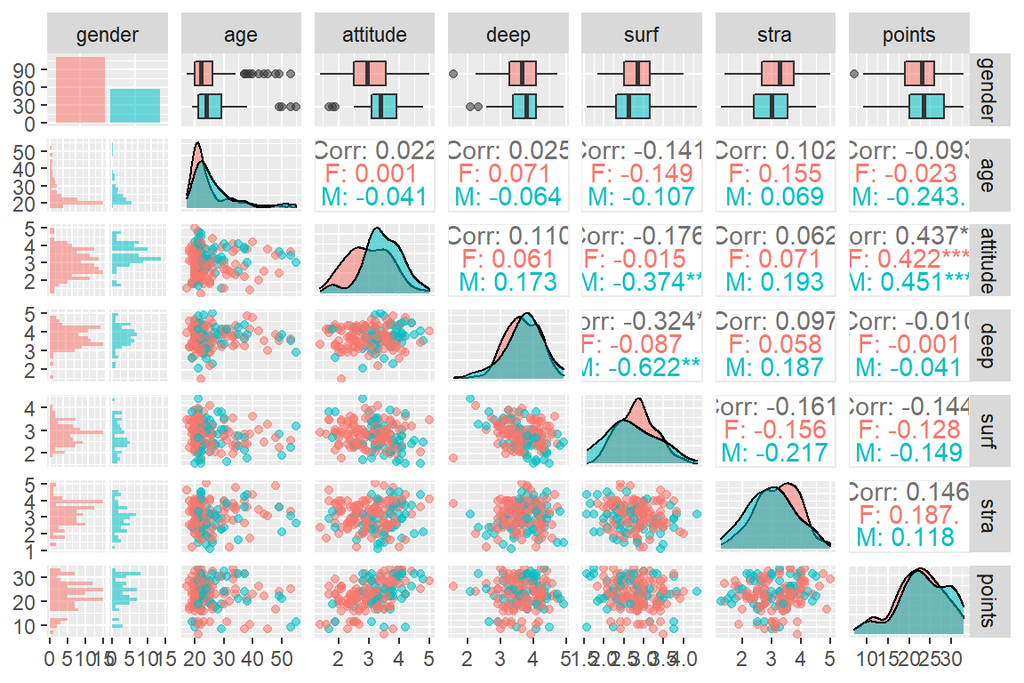

```r
library(ggplot2)
library(GGally)
p <- ggpairs(learn14, mapping = aes(col = gender, alpha = 0.3), lower = list(combo = wrap("facethist", bins = 20)))
p
```

Regression analysis:

I chose attitude, strategic questions and surface questions as my explanatory variables in the model as they had the highest correlation with exam points.

```r
lm_model <- lm(points ~ attitude + stra + surf, data = learn14)
summary(lm_model)
```

```
##
## Call:
## lm(formula = points ~ attitude + stra + surf, data = learn14)
##
## Residuals:
##      Min       1Q   Median       3Q      Max
## -17.1550  -3.4346   0.5156   3.6401  10.8952
##
## Coefficients:
##             Estimate Std. Error t value Pr(>|t|)
## (Intercept)  11.0171     3.6837   2.991  0.00322 **
## attitude      3.3952     0.5741   5.913 1.93e-08 ***
## stra          0.8531     0.5416   1.575  0.11716
## surf         -0.5861     0.8014  -0.731  0.46563
## ---
## Signif. codes:  0 '***' 0.001 '**' 0.01 '*' 0.05 '.' 0.1 ' ' 1
##
## Residual standard error: 5.296 on 162 degrees of freedom
## Multiple R-squared:  0.2074, Adjusted R-squared:  0.1927
## F-statistic: 14.13 on 3 and 162 DF,  p-value: 3.156e-08
```

The statistical test used in the model assumes the null hypothesis that an explanatory variable has no effect on the target variable. The *t* value represents the estimate of an explanatory variable divided by its standard error. A small standard error will result in higher *t* value. The p value represents the likelihood of obtaining this *t* value if the null hypothesis is true, small p value means that it is very unlikely that we can get the observed data distribution by chance.

According to the summary ‘attitude’ would have the highest effect on the target variable as its estimate is ~3.4 and would affect the slope of the model quite a bit. On the other hand ‘stra’ and ‘surf’ are 0.85 and -0.58 respectively and would have little effect on the tatget variable as their effect on the slope would be near zero.

Out of the three explanatory variables ‘attitude’ is the only one that has an interesting estimated value with also a correspondingly high *t* value and statistically significant p value. ‘stra’ and ‘surf’ on the other hand did not have statistically significant relationship with the target value as their p values were too high.

The strategic and surface level questions did not have statistically significant p values so I removed them from the next model.

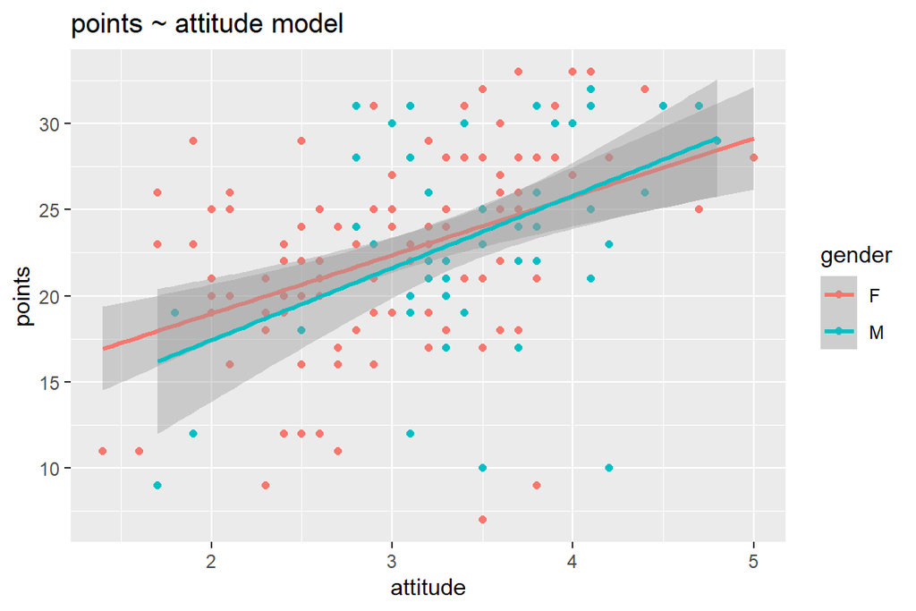

```r
library(ggplot2)
p <- ggplot(learn14, aes(x = attitude, y = points, col = gender)) + geom_point() + geom_smooth(method = "lm") + ggtitle("points ~ attitude model")
p
```

```r
lm_model <- lm(points ~ attitude, data = learn14)
summary(lm_model)
```

```
##
## Call:
## lm(formula = points ~ attitude, data = learn14)
##
## Residuals:
##      Min       1Q   Median       3Q      Max
## -16.9763  -3.2119   0.4339   4.1534  10.6645
##
## Coefficients:
##             Estimate Std. Error t value Pr(>|t|)
## (Intercept)  11.6372     1.8303   6.358 1.95e-09 ***
## attitude      3.5255     0.5674   6.214 4.12e-09 ***
## ---
## Signif. codes:  0 '***' 0.001 '**' 0.01 '*' 0.05 '.' 0.1 ' ' 1
##
## Residual standard error: 5.32 on 164 degrees of freedom
## Multiple R-squared:  0.1906, Adjusted R-squared:  0.1856
## F-statistic: 38.61 on 1 and 164 DF,  p-value: 4.119e-09
```

The significance of attitude increased and the p value is even smaller after removing the other two variables. The effect on the slope of the model also increased as the estimate for ‘attitude’ increased to 3.5.

Multiple R-squared represents how much of the target variable can be explained by the explanatory variables, the higher the value the better the model is generally considered to be. In this case the model with only attitude variable can explain around 19% of the variance seen in the points variable.

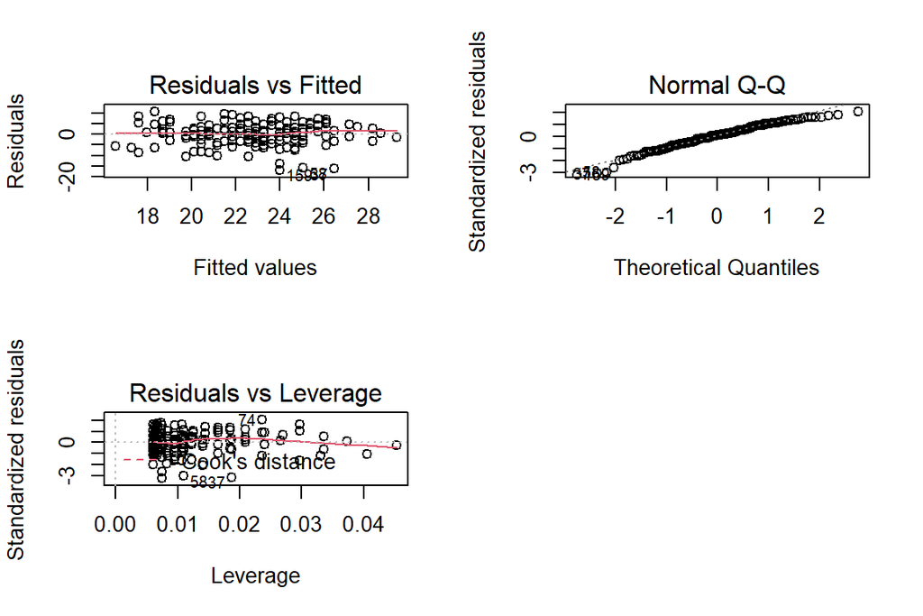

```r
par(mfrow =c(2,2))
plot(lm_model, which = c(1,2,5))
```

In linear regression we assume that the relationship between the target value and explanatory variables is linear, which we can see in the points ~ attitude plot where the regression lines are clearly diagonal.

General assumptions about the errors in the model are that they are normally distributed, are not correlated and have constant variance. If for example variance is not constant we can see that the residues would disperse in the plots. Errors are also not dependent on any of the variables in the model.

Normality can be observed in the QQ plot where if the residues are normally distributed they will mostly fall on the diagonal line. In my opinion normality holds in this case as most of the points are on the diagonal line and none of them look like they are very far from it if they are not on it.

In the residuals vs fitted plot we can see that there is no pattern or dispersion of the points meaning that the variance of the errors is constant as expected.

There are also not any significant outliers as the Cook’s distance is small for all data points as can be observed in the leverage plot.

# Week 3, logistic regression

## Exercise 3

The data in this exercise consists of student questionnaire that measured student performance in mathematics and Portuguese language. The questionnaires were performed in two Portuguese high schools in 2008. The data set includes background information about the students’ families, use of time such as study and free time, health information such as a score for overall health and alcohol consumption. Student performance variables include information about the grades and absences. The data includes both categorical data and integer data where lower numbers indicate lower score and higher numbers higher score or satisfaction.

```r
student_data <- read.table('data/joint_student_data.tsv', sep = '\t', header = TRUE)

colnames(student_data)
```

```
##  [1] "school"     "sex"        "age"        "address"    "famsize"
##  [6] "Pstatus"    "Medu"       "Fedu"       "Mjob"       "Fjob"
## [11] "reason"     "guardian"   "traveltime" "studytime"  "schoolsup"
## [16] "famsup"     "activities" "nursery"    "higher"     "internet"
## [21] "romantic"   "famrel"     "freetime"   "goout"      "Dalc"
## [26] "Walc"       "health"     "failures"   "paid"       "absences"
## [31] "G1"         "G2"         "G3"         "alc_use"    "high_use"
```

Potentially interesting variables in my opinion are: age, goout, sex, and health.

I think age is an interesting variable as I would expect that older students are more likely to drink or drink heavily in comparison to younger students.

The goout variable refers to going out with friends. As drinking alcohol is often done in social situation such as parties rather than alone I would expect that students who go out a lot with their friends would also drink more. More introverted students would also be less likely to have friends who can acquire alcohol as they likely have less friends overall than more sociable students.

I would also expect to see a sex difference between boys and girls as adult men tend to drink more than women and thus I expect to see this difference already reflected in students. I also expect that boys are overall heavier drinkers than girls as boys are able to metabolize higher quantities of alcohol and are more likely to engage in risky behavior.

The health variable is about the overall health status with low numbers referring to low health and high ones to better health. Excessive drinking could be related to lower overall health.

```r
library(plyr)
library(dplyr)
plyr::count(student_data$sex)
```

```
##   x freq
## 1 F  195
## 2 M  175
```

```r
summary(student_data$goout)
```

```
##    Min. 1st Qu.  Median    Mean 3rd Qu.    Max.
##   1.000   2.000   3.000   3.116   4.000   5.000
```

```r
summary(student_data$age)
```

```
##    Min. 1st Qu.  Median    Mean 3rd Qu.    Max.
##   15.00   16.00   17.00   16.58   17.00   22.00
```

```r
summary(student_data$health)
```

```
##    Min. 1st Qu.  Median    Mean 3rd Qu.    Max.
##   1.000   3.000   4.000   3.562   5.000   5.000
```

```r
student_data %>% group_by(high_use) %>% dplyr::summarise(count = n(), mean_health = mean(health), mean_goout = mean(goout), mean_age = mean(age))
```

```
## # A tibble: 2 x 5
##   high_use count mean_health mean_goout mean_age
##   <lgl>    <int>       <dbl>      <dbl>    <dbl>
## 1 FALSE      259        3.49       2.85     16.5
## 2 TRUE       111        3.73       3.73     16.8
```

```r
student_data %>% group_by(sex, high_use) %>% dplyr::summarise(count = n(), mean_health = mean(health), mean_goout = mean(goout), mean_age = mean(age))
```

```
## # A tibble: 4 x 6
## # Groups:   sex [2]
##   sex   high_use count mean_health mean_goout mean_age
##   <chr> <lgl>    <int>       <dbl>      <dbl>    <dbl>
## 1 F     FALSE      154        3.37       2.95     16.6
## 2 F     TRUE        41        3.39       3.39     16.5
## 3 M     FALSE      105        3.67       2.70     16.3
## 4 M     TRUE        70        3.93       3.93     16.9
```

In the data I have 195 female students and 175 male students. I think this is overall a good distribution and not too biased one way.

The age range of students varies from 15 to 22 with the mean being 16.6. The legal age of drinking wine and beer in Portugal was 16 before a new law introduced in 2015 so most students would have been legally allowed to drink milder alcoholic drinks when the questionnaire was performed but not allowed to drink spirits for which the legal drinking age was 18. A breakdown of students into high and low alcohol users shows that high users are a little older than low users. This is as I expect in my hypothesis. Interestingly girls who are older are less likely to be high alcohol users while older boys are more likely to use alcohol a lot.

The mean value of goout is 3.1 and median 3 so overall students tend to go out not too rarely but not too often either. Like I hypothesized high alcohol users are more likely to go out with their friends. High alcohol user boys are especially likely to go out with their friends while boys who are low alcohol users are the least likely to go out with their friends. Girls who use high quantities of alcohol are also more likely to go out but the comparison to low alcohol using girls is less extreme.

The mean health score is 3.6 so students overall have okay to good health. Interestingly the health of students who are high alcohol users is higher thant that of students who are low users which is not what I expected. Boys who are high alcohol users report the highest health scores while girls who are low alcohol users report the lowest score with girls’ health overall being worse than boys’.

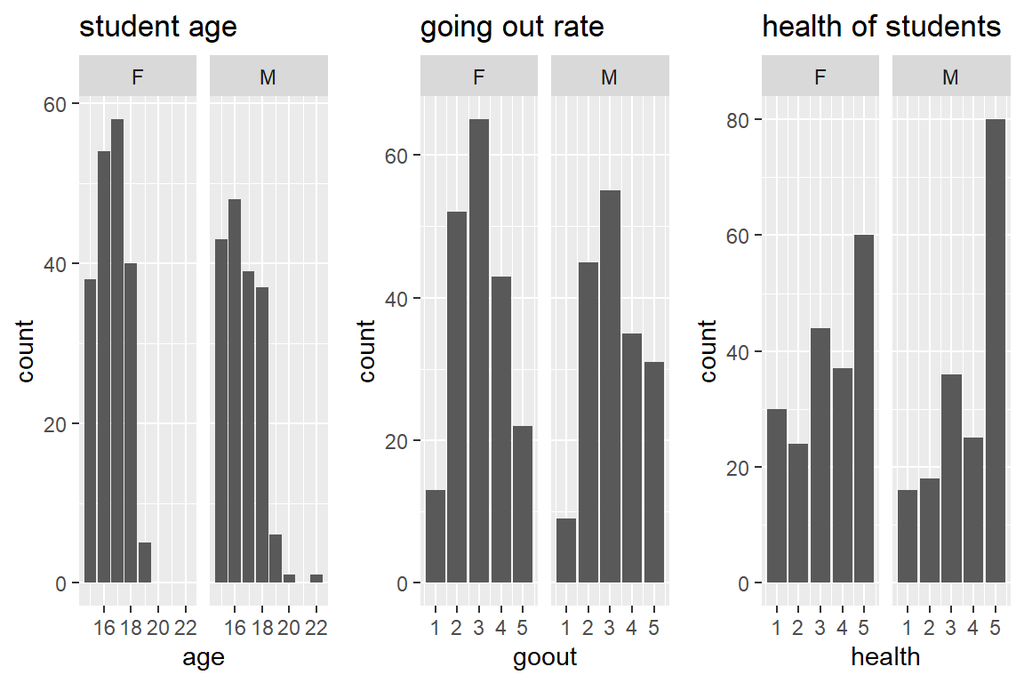

```r
library(ggplot2)
library(gridExtra)
bar1 <- ggplot(data = student_data, aes(x = age)) + geom_bar() + facet_wrap("sex") + ggtitle("student age")
bar2 <- ggplot(data = student_data, aes(x = goout)) + geom_bar() + facet_wrap("sex") + ggtitle("going out rate")
bar3 <- ggplot(data = student_data, aes(x = health)) + geom_bar() + facet_wrap("sex") + ggtitle("health of students")

grid.arrange(bar1, bar2, bar3, ncol = 3)
```

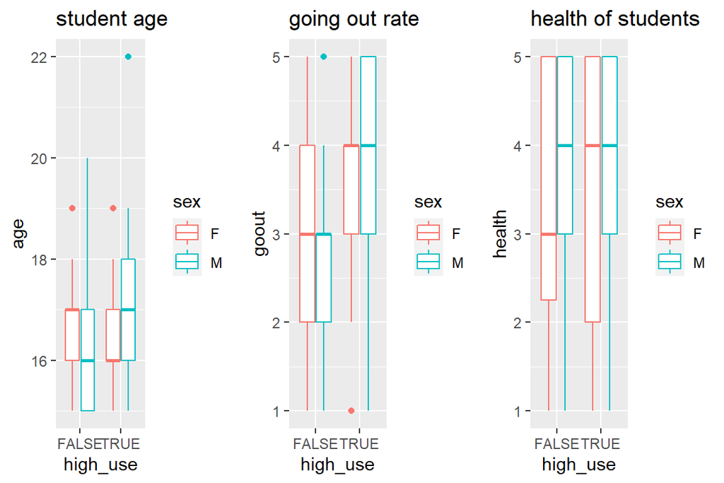

```r
bar1 <- ggplot(data = student_data, aes(y = age, x = high_use, col = sex)) + geom_boxplot() + ggtitle("student age")
bar2 <- ggplot(data = student_data, aes(y = goout, x = high_use, col = sex)) + geom_boxplot() + ggtitle("going out rate")
bar3 <- ggplot(data = student_data, aes(y = health, x = high_use, col = sex)) + geom_boxplot()  + ggtitle("health of students")

grid.arrange(bar1, bar2, bar3, ncol = 3)
```

I do not think the bar or box plots reveal much information that was not available from the numeric analysis. Though it can be seen that boys were very likely to rate their health as excellent and girls were much more likely to rate their health as poor.

I think overall my hypotheses were true, older students are more likely to drink as I expected but this differs when broken down by sex as younger girls are more likely to drink. Boys are also more likely to be heavier drinkers as there are proportionally and in numerically more heavy drinking boys than girls. As I hypothesized students who go tout are more likely to be heavy drinkers. What did not match my hypothesis is the health information as students who were heavy drinkers were more likely to report better health.

Logistic regression of the variables:

```r
model <- glm(high_use ~ age + sex + goout + health, data = student_data, family = 'binomial')

summary(model)
```

```
##
## Call:
## glm(formula = high_use ~ age + sex + goout + health, family = "binomial",
##     data = student_data)
##
## Deviance Residuals:
##     Min       1Q   Median       3Q      Max
## -1.7018  -0.8219  -0.5633   0.8516   2.5724
##
## Coefficients:
##             Estimate Std. Error z value Pr(>|z|)
## (Intercept) -6.15094    1.84515  -3.334 0.000857 ***
## age          0.11969    0.10680   1.121 0.262434
## sexM         0.88692    0.25414   3.490 0.000483 ***
## goout        0.74476    0.12026   6.193  5.9e-10 ***
## health       0.11321    0.09154   1.237 0.216194
## ---
## Signif. codes:  0 '***' 0.001 '**' 0.01 '*' 0.05 '.' 0.1 ' ' 1
##
## (Dispersion parameter for binomial family taken to be 1)
##
##     Null deviance: 452.04  on 369  degrees of freedom
## Residual deviance: 386.26  on 365  degrees of freedom
## AIC: 396.26
##
## Number of Fisher Scoring iterations: 4
```

Based on the model the sex of the student and goout are statistically significant factors in determining if a student is heavy alcohol user or not if we assume that p-values less than 0.05 are significant. On th other hand age and health are not. Going out rate is the most significant factor according to the model. The intercept difference between female and male students is approximately 0.89.

```r
coef(model)
```

```
## (Intercept)         age        sexM       goout      health
##  -6.1509434   0.1196852   0.8869160   0.7447587   0.1132094
```

```r
OR <- coef(model) %>% exp
CI <- confint(model) %>% exp
cbind(OR, CI)
```

```
##                     OR        2.5 %     97.5 %
## (Intercept) 0.00213147 5.296297e-05 0.07489302
## age         1.12714196 9.149491e-01 1.39232923
## sexM        2.42763124 1.481924e+00 4.02156299
## goout       2.10593314 1.673832e+00 2.68477691
## health      1.11986646 9.374958e-01 1.34344586
```

Out of the coefficients sexM has the widest confidence interval. Age and health odds ratios are very close to one so while they have a minor effect in predicting who of the students is a high alcohol user they overall do not matter. On the other hand if the sex of the student is male then it is 2.4 times more likely for the student to be a high alcohol user than if the student was female. Similarly outgoing students are 2.1 times more likely to be high alcohol users compared to students who do not go out often.

Predicting whom of the students is a high alcohol user:

```r
model2 <- glm(high_use ~ sex + goout, data = student_data, family = 'binomial')

summary(model2)
```

```
##
## Call:
## glm(formula = high_use ~ sex + goout, family = "binomial", data = student_data)
##
## Deviance Residuals:
##     Min       1Q   Median       3Q      Max
## -1.5740  -0.8658  -0.6216   0.8272   2.4929
##
## Coefficients:
##             Estimate Std. Error z value Pr(>|z|)
## (Intercept)  -3.8193     0.4572  -8.354  < 2e-16 ***
## sexM          0.9268     0.2507   3.696 0.000219 ***
## goout         0.7578     0.1190   6.369  1.9e-10 ***
## ---
## Signif. codes:  0 '***' 0.001 '**' 0.01 '*' 0.05 '.' 0.1 ' ' 1
##
## (Dispersion parameter for binomial family taken to be 1)
##
##     Null deviance: 452.04  on 369  degrees of freedom
## Residual deviance: 388.94  on 367  degrees of freedom
## AIC: 394.94
##
## Number of Fisher Scoring iterations: 4
```

```r
predicted_prob <- predict(model2, type = "response")
student_data <- mutate(student_data, predicted_probability = predicted_prob)
student_data <- mutate(student_data, predicted_value = student_data$predicted_probability > 0.5)

table(high_use = student_data$high_use, prediction = student_data$predicted_value)
```

```
##         prediction
## high_use FALSE TRUE
##    FALSE   242   17
##    TRUE     62   49
```

```r
table(high_use = student_data$high_use, prediction = student_data$predicted_value) %>% prop.table() %>% addmargins()
```

```
##         prediction
## high_use      FALSE       TRUE        Sum
##    FALSE 0.65405405 0.04594595 0.70000000
##    TRUE  0.16756757 0.13243243 0.30000000
##    Sum   0.82162162 0.17837838 1.00000000
```

Based on the cross tabulation we can see that the prediction rate for false cases as false is 65.4% and true cases as true 13.2%. The false positive rate is 4.6% and false negative is 16.8%. The model thus overall seems to do worse when predicting who is a high alcohol user and is more likely to predict high alcohol users as low alcohol users than low alcohol users as high alcohol users.

```r
plyr::count(student_data$high_use == student_data$predicted_value)
```

```
##       x freq
## 1 FALSE   79
## 2  TRUE  291
```

```r
loss_func <- function(class, prob) {
  n_wrong <- abs(class - prob) > 0.5
  mean(n_wrong)
}

loss_func(class = student_data$high_use, prob = student_data$predicted_value)
```

```
## [1] 0.2135135
```

I have a total of 79 incorrectly predicted individuals and the overall training error rate is 21%. This is not very good when predicting if a student is a heavy alcohol user as the model predicts every fifth student wrong and ideally our model would be basically never wrong if we wanted accurate predictions.

```r
student_data$guess <- sample(c(TRUE, FALSE),370, TRUE, c(0.5,0.5))

plyr::count(student_data$guess)
```

```
##       x freq
## 1 FALSE  187
## 2  TRUE  183
```

```r
loss_func(class = student_data$high_use, prob = student_data$guess)
```

```
## [1] 0.4810811
```

If we guess with a 50% chance of each student being a high alcohol user we get are wrong approximately half the time as the error rate is around 50%. Based on this the model is better than mere random guessing and is at least mildly useful in predicting who is a high alcohol user among the students.

Simple 10-fold cross validation:

```r
library(boot)
cv10 <- cv.glm(data = student_data, cost = loss_func, glmfit = model2, K = 10)

cv10$delta[1]
```

```
## [1] 0.2486486
```

My overall conclusion of this exercise is that my hypothesis regarding the student age and health showing a connection between high alcohol use was wrong. These variables did not have a statistically significant relationship between alcohol consumption. On the other hand my hypothesis regarding male students and outgoing students being more likely to be high alcohol users were correct. Additionally I managed to make a model that was slightly better than the datacamp one.

# Week 4, clustering and classification

## Exercise 4

In this exercise we use a data set called “Boston”, which contains data gathered from the city of Boston. The data set for example contains information about housing such as value of houses, property tax, and number of rooms in a house. Other data include for example crime rates, pollution rates, zoning, and accessibility to highways.

```r
library(MASS)
data("Boston")

dim(Boston)
```

```
## [1] 506  14
```

```r
str(Boston)
```

```
## 'data.frame':    506 obs. of  14 variables:
##  $ crim   : num  0.00632 0.02731 0.02729 0.03237 0.06905 ...
##  $ zn     : num  18 0 0 0 0 0 12.5 12.5 12.5 12.5 ...
##  $ indus  : num  2.31 7.07 7.07 2.18 2.18 2.18 7.87 7.87 7.87 7.87 ...
##  $ chas   : int  0 0 0 0 0 0 0 0 0 0 ...
##  $ nox    : num  0.538 0.469 0.469 0.458 0.458 0.458 0.524 0.524 0.524 0.524 ...
##  $ rm     : num  6.58 6.42 7.18 7 7.15 ...
##  $ age    : num  65.2 78.9 61.1 45.8 54.2 58.7 66.6 96.1 100 85.9 ...
##  $ dis    : num  4.09 4.97 4.97 6.06 6.06 ...
##  $ rad    : int  1 2 2 3 3 3 5 5 5 5 ...
##  $ tax    : num  296 242 242 222 222 222 311 311 311 311 ...
##  $ ptratio: num  15.3 17.8 17.8 18.7 18.7 18.7 15.2 15.2 15.2 15.2 ...
##  $ black  : num  397 397 393 395 397 ...
##  $ lstat  : num  4.98 9.14 4.03 2.94 5.33 ...
##  $ medv   : num  24 21.6 34.7 33.4 36.2 28.7 22.9 27.1 16.5 18.9 ...
```

The Boston data set has 14 columns and 506 rows and all of the data is numeric.

```r
library(ggplot2)
library(GGally)
library(corrplot)
summary(Boston)
```

```
##       crim                zn             indus            chas
##  Min.   : 0.00632   Min.   :  0.00   Min.   : 0.46   Min.   :0.00000
##  1st Qu.: 0.08205   1st Qu.:  0.00   1st Qu.: 5.19   1st Qu.:0.00000
##  Median : 0.25651   Median :  0.00   Median : 9.69   Median :0.00000
##  Mean   : 3.61352   Mean   : 11.36   Mean   :11.14   Mean   :0.06917
##  3rd Qu.: 3.67708   3rd Qu.: 12.50   3rd Qu.:18.10   3rd Qu.:0.00000
##  Max.   :88.97620   Max.   :100.00   Max.   :27.74   Max.   :1.00000
##       nox               rm             age              dis
##  Min.   :0.3850   Min.   :3.561   Min.   :  2.90   Min.   : 1.130
##  1st Qu.:0.4490   1st Qu.:5.886   1st Qu.: 45.02   1st Qu.: 2.100
##  Median :0.5380   Median :6.208   Median : 77.50   Median : 3.207
##  Mean   :0.5547   Mean   :6.285   Mean   : 68.57   Mean   : 3.795
##  3rd Qu.:0.6240   3rd Qu.:6.623   3rd Qu.: 94.08   3rd Qu.: 5.188
##  Max.   :0.8710   Max.   :8.780   Max.   :100.00   Max.   :12.127
##       rad              tax           ptratio          black
##  Min.   : 1.000   Min.   :187.0   Min.   :12.60   Min.   :  0.32
##  1st Qu.: 4.000   1st Qu.:279.0   1st Qu.:17.40   1st Qu.:375.38
##  Median : 5.000   Median :330.0   Median :19.05   Median :391.44
##  Mean   : 9.549   Mean   :408.2   Mean   :18.46   Mean   :356.67
##  3rd Qu.:24.000   3rd Qu.:666.0   3rd Qu.:20.20   3rd Qu.:396.23
##  Max.   :24.000   Max.   :711.0   Max.   :22.00   Max.   :396.90
##      lstat            medv
##  Min.   : 1.73   Min.   : 5.00
##  1st Qu.: 6.95   1st Qu.:17.02
##  Median :11.36   Median :21.20
##  Mean   :12.65   Mean   :22.53
##  3rd Qu.:16.95   3rd Qu.:25.00
##  Max.   :37.97   Max.   :50.00
```

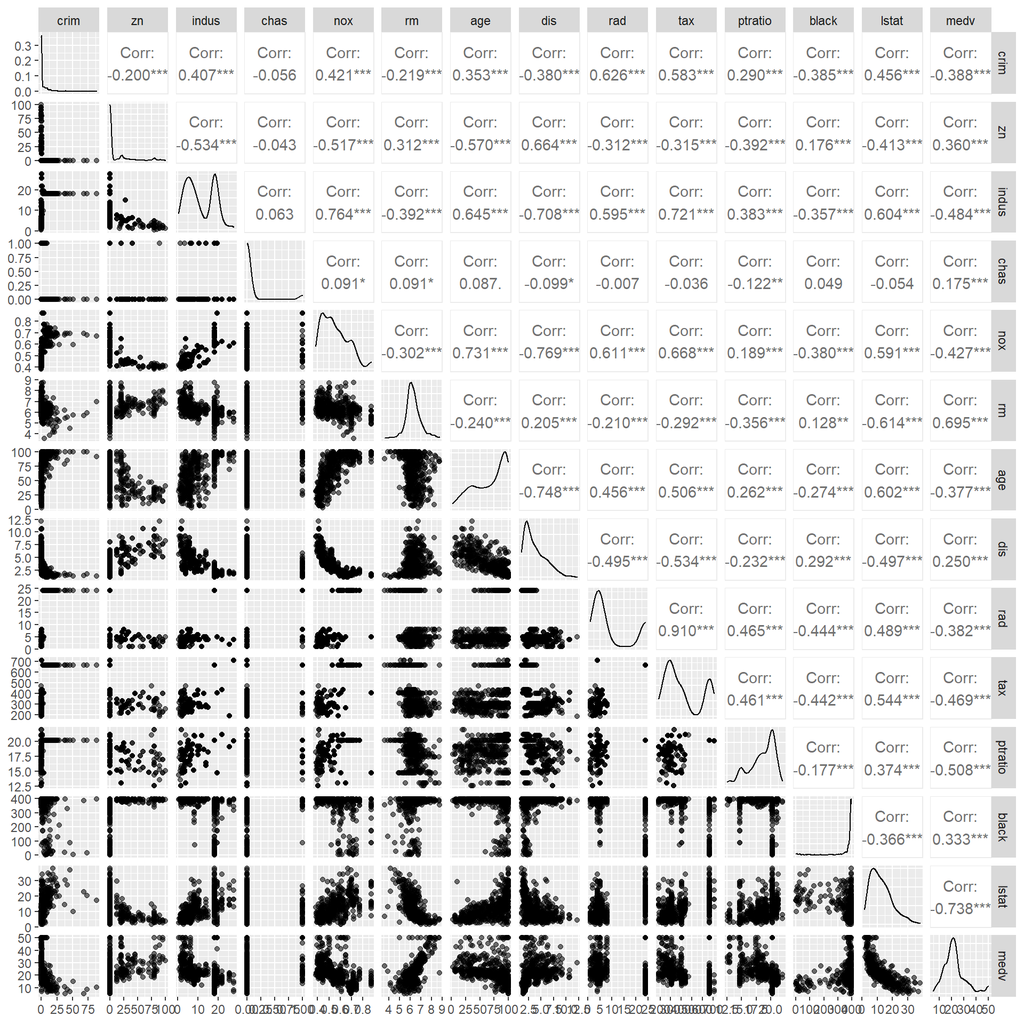

```r
p <- ggpairs(Boston, mapping = aes(alpha = 0.3), lower = list(combo = wrap("facethist", bins = 20)))
p
```

```r
cor_matrix<-cor(Boston)
cor_matrix %>% round(2)
```

```
##          crim    zn indus  chas   nox    rm   age   dis   rad   tax ptratio
## crim     1.00 -0.20  0.41 -0.06  0.42 -0.22  0.35 -0.38  0.63  0.58    0.29
## zn      -0.20  1.00 -0.53 -0.04 -0.52  0.31 -0.57  0.66 -0.31 -0.31   -0.39
## indus    0.41 -0.53  1.00  0.06  0.76 -0.39  0.64 -0.71  0.60  0.72    0.38
## chas    -0.06 -0.04  0.06  1.00  0.09  0.09  0.09 -0.10 -0.01 -0.04   -0.12
## nox      0.42 -0.52  0.76  0.09  1.00 -0.30  0.73 -0.77  0.61  0.67    0.19
## rm      -0.22  0.31 -0.39  0.09 -0.30  1.00 -0.24  0.21 -0.21 -0.29   -0.36
## age      0.35 -0.57  0.64  0.09  0.73 -0.24  1.00 -0.75  0.46  0.51    0.26
## dis     -0.38  0.66 -0.71 -0.10 -0.77  0.21 -0.75  1.00 -0.49 -0.53   -0.23
## rad      0.63 -0.31  0.60 -0.01  0.61 -0.21  0.46 -0.49  1.00  0.91    0.46
## tax      0.58 -0.31  0.72 -0.04  0.67 -0.29  0.51 -0.53  0.91  1.00    0.46
## ptratio  0.29 -0.39  0.38 -0.12  0.19 -0.36  0.26 -0.23  0.46  0.46    1.00
## black   -0.39  0.18 -0.36  0.05 -0.38  0.13 -0.27  0.29 -0.44 -0.44   -0.18
## lstat    0.46 -0.41  0.60 -0.05  0.59 -0.61  0.60 -0.50  0.49  0.54    0.37
## medv    -0.39  0.36 -0.48  0.18 -0.43  0.70 -0.38  0.25 -0.38 -0.47   -0.51
##         black lstat  medv
## crim    -0.39  0.46 -0.39
## zn       0.18 -0.41  0.36
## indus   -0.36  0.60 -0.48
## chas     0.05 -0.05  0.18
## nox     -0.38  0.59 -0.43
## rm       0.13 -0.61  0.70
## age     -0.27  0.60 -0.38
## dis      0.29 -0.50  0.25
## rad     -0.44  0.49 -0.38
## tax     -0.44  0.54 -0.47
## ptratio -0.18  0.37 -0.51
## black    1.00 -0.37  0.33
## lstat   -0.37  1.00 -0.74
## medv     0.33 -0.74  1.00
```

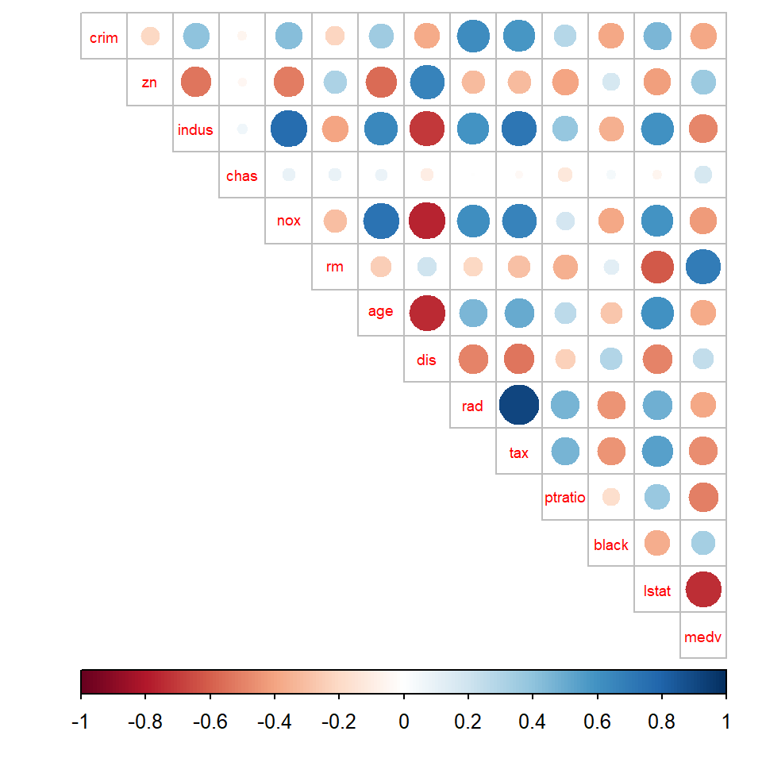

```r
corrplot(cor_matrix, method="circle", type = "upper", cl.pos = "b", tl.pos = "d", tl.cex = 0.6)
```

Based on the plots most of the columns do not seem to follow the normal distribution and instead we can see multiple peaks in the data. There seems to be strong negative correlations between ‘dis’ and ‘indus’ (non-retail business) , ‘nox’ (nitrogen oxides) , and ‘age’ (built prior to 1940). A very strong correlation can also be seen between ‘lstat’ (lower status population) and ‘medv’ (median value of homes). It is not particularly surprising that lower status population could afford only cheaper homes.

A strong positive correlation seems to exits between ‘rad’ (access to radial highways) and ‘tax’ (property tax) as well as ‘indus’ and ‘nox’ and between ‘nox’ and ‘age’. It is again not that surprising that areas with more industry would have higher nitrogen oxide levels.

In the summary we can see that crime rates vary from very low with a minimum of 0.006 to very high with a crime rate of 88.98. The median is closer to the low rate so this very high rate is clearly some kind of anomaly within Boston and not reflective of the entire city.

The age variable indicates that there are areas in Boston where almost no houses are old and then there are areas where are houses are old. But old houses seem to be common overall as the first quantile is at 45%.

Standardizing data:

```r
boston_stand <- as.data.frame(scale(Boston))
summary(boston_stand)
```

```
##       crim                 zn               indus              chas
##  Min.   :-0.419367   Min.   :-0.48724   Min.   :-1.5563   Min.   :-0.2723
##  1st Qu.:-0.410563   1st Qu.:-0.48724   1st Qu.:-0.8668   1st Qu.:-0.2723
##  Median :-0.390280   Median :-0.48724   Median :-0.2109   Median :-0.2723
##  Mean   : 0.000000   Mean   : 0.00000   Mean   : 0.0000   Mean   : 0.0000
##  3rd Qu.: 0.007389   3rd Qu.: 0.04872   3rd Qu.: 1.0150   3rd Qu.:-0.2723
##  Max.   : 9.924110   Max.   : 3.80047   Max.   : 2.4202   Max.   : 3.6648
##       nox                rm               age               dis
##  Min.   :-1.4644   Min.   :-3.8764   Min.   :-2.3331   Min.   :-1.2658
##  1st Qu.:-0.9121   1st Qu.:-0.5681   1st Qu.:-0.8366   1st Qu.:-0.8049
##  Median :-0.1441   Median :-0.1084   Median : 0.3171   Median :-0.2790
##  Mean   : 0.0000   Mean   : 0.0000   Mean   : 0.0000   Mean   : 0.0000
##  3rd Qu.: 0.5981   3rd Qu.: 0.4823   3rd Qu.: 0.9059   3rd Qu.: 0.6617
##  Max.   : 2.7296   Max.   : 3.5515   Max.   : 1.1164   Max.   : 3.9566
##       rad               tax             ptratio            black
##  Min.   :-0.9819   Min.   :-1.3127   Min.   :-2.7047   Min.   :-3.9033
##  1st Qu.:-0.6373   1st Qu.:-0.7668   1st Qu.:-0.4876   1st Qu.: 0.2049
##  Median :-0.5225   Median :-0.4642   Median : 0.2746   Median : 0.3808
##  Mean   : 0.0000   Mean   : 0.0000   Mean   : 0.0000   Mean   : 0.0000
##  3rd Qu.: 1.6596   3rd Qu.: 1.5294   3rd Qu.: 0.8058   3rd Qu.: 0.4332
##  Max.   : 1.6596   Max.   : 1.7964   Max.   : 1.6372   Max.   : 0.4406
##      lstat              medv
##  Min.   :-1.5296   Min.   :-1.9063
##  1st Qu.:-0.7986   1st Qu.:-0.5989
##  Median :-0.1811   Median :-0.1449
##  Mean   : 0.0000   Mean   : 0.0000
##  3rd Qu.: 0.6024   3rd Qu.: 0.2683
##  Max.   : 3.5453   Max.   : 2.9865
```

```r
bins <- quantile(boston_stand$crim)
bins
```

```
##           0%          25%          50%          75%         100%
## -0.419366929 -0.410563278 -0.390280295  0.007389247  9.924109610
```

```r
crime <- cut(boston_stand$crim, breaks = bins, include.lowest = TRUE, label = c("low", "med_low", "med_high", "high"))

boston_stand$crim <- crime #no need to remove the crime column when it can be just replaced

table(crime)
```

```
## crime
##      low  med_low med_high     high
##      127      126      126      127
```

Since the data has bee scaled it now is distributed around a 0 mean so all variables have a 0 mean in the summary.

The distribution of crime rates seem to be approximately equally distributed between the four crime levels.

Fitting a LDA model and drawing a plot:

```r
n <- nrow(boston_stand)
ind <- sample(n, size = n*0.8) #splitting data into train and test sets
train <- boston_stand[ind,]
test <- boston_stand[-ind,]
```

```r
lda.fit <- lda(crim ~ ., data = train)
lda.fit
```

```
## Call:
## lda(crim ~ ., data = train)
##
## Prior probabilities of groups:
##       low   med_low  med_high      high
## 0.2574257 0.2425743 0.2376238 0.2623762
##
## Group means:
##                   zn      indus        chas        nox          rm        age
## low       0.92234567 -0.8983264 -0.12090214 -0.8584389  0.44647665 -0.8439984
## med_low  -0.06043767 -0.2661616  0.04906687 -0.5645570 -0.14460759 -0.3363823
## med_high -0.39612627  0.2112368  0.09677408  0.4194684 -0.03962716  0.4228300
## high     -0.48724019  1.0170298 -0.08661679  1.0624675 -0.41077210  0.8300414
##                 dis        rad        tax     ptratio       black       lstat
## low       0.8575732 -0.6925458 -0.7633370 -0.39251074  0.38924916 -0.76871056
## med_low   0.3581598 -0.5459225 -0.4652425 -0.04591854  0.31250443 -0.16026914
## med_high -0.3539389 -0.4590794 -0.3100681 -0.16951555  0.04598001  0.08989374
## high     -0.8661338  1.6390172  1.5146914  0.78181164 -0.76958775  0.92932552
##                  medv
## low       0.551791731
## med_low  -0.003677976
## med_high  0.061670899
## high     -0.706823669
##
## Coefficients of linear discriminants:
##                  LD1           LD2         LD3
## zn       0.084044875  0.6261651776 -0.89289850
## indus    0.040735400 -0.1152391303  0.42203180
## chas     0.011228835 -0.0141794157  0.22733733
## nox      0.350122345 -0.9124049693 -1.46941969
## rm      -0.008011734  0.0003568721 -0.17109928
## age      0.192721352 -0.3032740753 -0.14847599
## dis     -0.057276418 -0.2720379122  0.09157302
## rad      3.608363147  1.1452732999 -0.13635018
## tax      0.113438678 -0.1978931423  0.65375893
## ptratio  0.129744290 -0.1141835511 -0.41391911
## black   -0.073191052  0.0741985349  0.13470096
## lstat    0.119917637 -0.1965094089  0.28123815
## medv     0.023023728 -0.4506983061 -0.30368062
##
## Proportion of trace:
##    LD1    LD2    LD3
## 0.9615 0.0286 0.0099
```

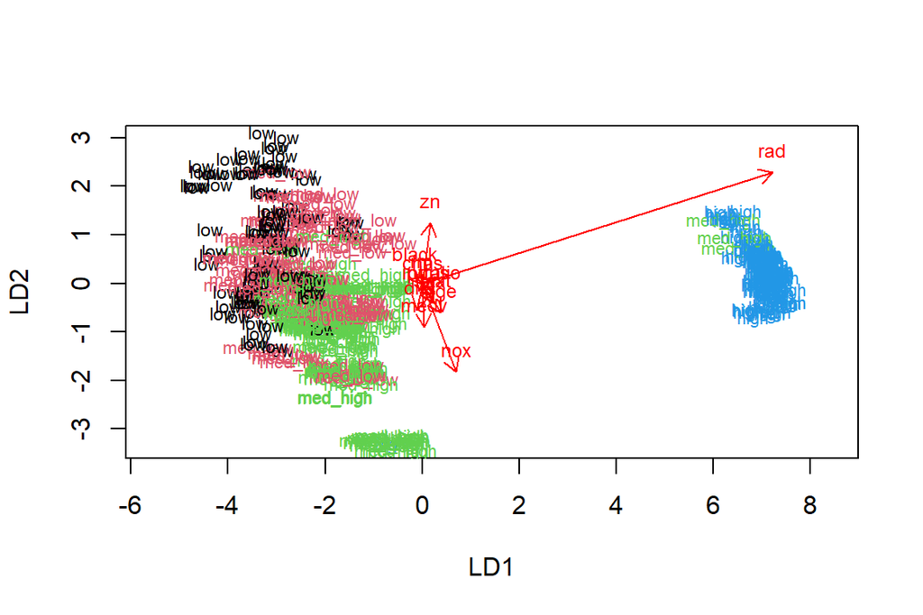

```r
#copied from the datacamp exercise

lda.arrows <- function(x, myscale = 1, arrow_heads = 0.1, color = "red", tex = 0.75, choices = c(1,2)){
  heads <- coef(x)
  arrows(x0 = 0, y0 = 0,
         x1 = myscale * heads[,choices[1]],
         y1 = myscale * heads[,choices[2]], col=color, length = arrow_heads)
  text(myscale * heads[,choices], labels = row.names(heads),
       cex = tex, col=color, pos=3)
}

classes <- as.numeric(train$crim)

plot(lda.fit, dimen = 2, col = classes, pch = classes)
lda.arrows(lda.fit, myscale = 2)
```

The high crime rate and some medium high crime rate datapoints seem to form their own cluster. ‘rad’ (accessibility to radial highways) seems to be the feature that separates this cluster from the others. In the previous correlation plots we can see that there is indeed a positive correaltion between crime rate and ‘rad’.

‘zn’ and ‘nox’ seem to separate the other axis. In this case it separates out the lower crime areas from the medium high ones. The ‘zn’ (residential lots) and ‘nox’ (nitrogen oxide levels) probably correlate between more quiet residential areas and industrial areas or areas near them.

Predicting:

```r
correct <- test$crim
test <- dplyr::select(test, -crim)

lda.pred <- predict(lda.fit, newdata = test)
table(correct = correct, predicted = lda.pred$class)
```

```
##           predicted
## correct    low med_low med_high high
##   low       15       7        1    0
##   med_low    5      19        4    0
##   med_high   1       8       18    3
##   high       0       0        0   21
```

The model seems to predict well the high crime rates, but has trouble separating the medium crime levels. Predicting low crime rates works quite well, but the model has trouble separating the low and medium low rates from each other. Similarly the model has problems separating medium low and medium high rates from each other.

Clustering with k-means:

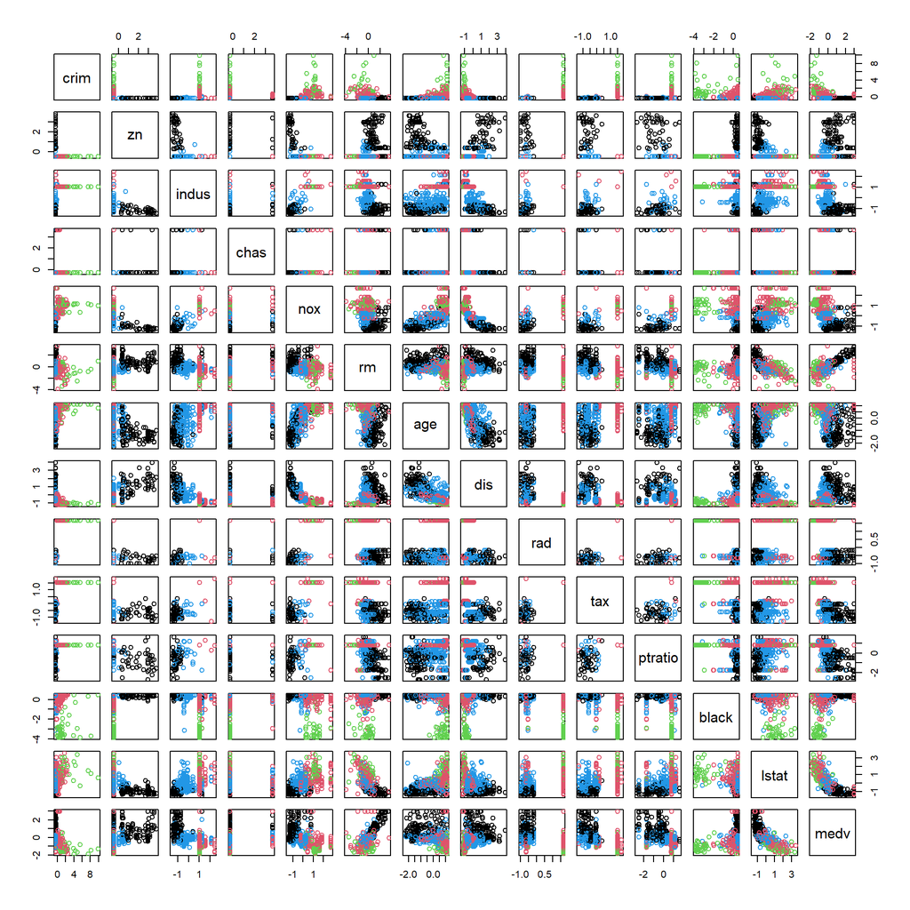

```r
data("Boston")
scaled_boston <- scale(Boston)

dist_eu <- dist(scaled_boston)

km <-kmeans(scaled_boston, centers = 4)

pairs(scaled_boston, col = km$cluster)
```

4 clusters does not seem to be all that great as there is still overlap between the different clusters and as the LDA prediction indicated a lower number of clusters is probably better since there is confusion between the classes.

Investigating how many clusters would be good:

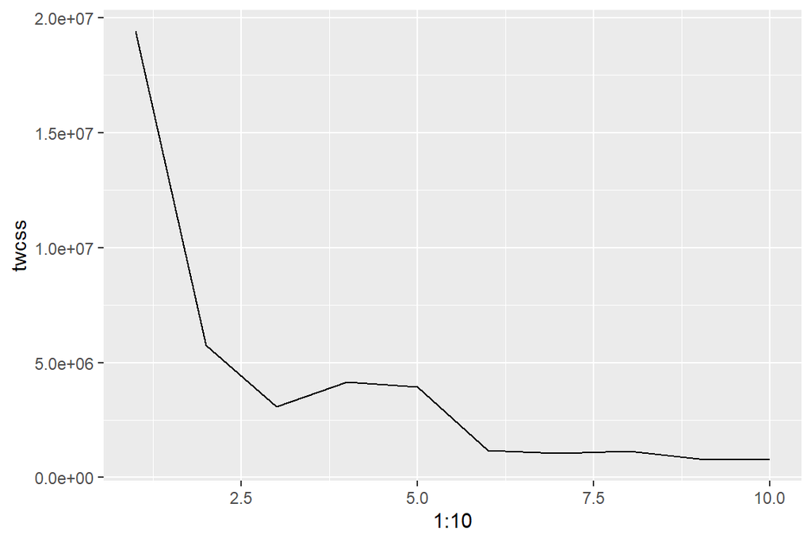

```r
twcss <- sapply(1:10, function(k){kmeans(Boston, k)$tot.withinss})
qplot(x = 1:10, y = twcss, geom = 'line')
```

According to the plot 2 clusters seems to be a good number to try.

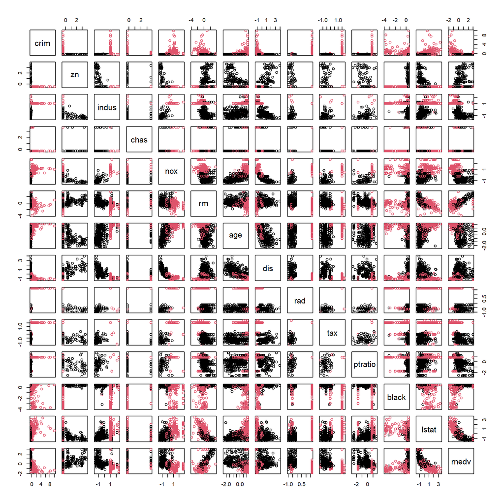

```r
km <-kmeans(scaled_boston, centers = 2)
pairs(scaled_boston, col = km$cluster)
```

Now we can see the clusters much easily. It is probably better in the model to separate the crime rate into a high one and low to medium levels.

In the plots we can see for example in the ‘lstat’ and ‘medv’ a clear separation between the two clusters and it would be easy to draw a straight line between them to separate the to clusters. There are also plots where the two clusters are completely separate from each other.

# Week 5, dimensionality reduction

## Exercise 5

The data set used in this exercise is about country specific human development index (HDI) and gender inequality index (GII).HDI measures the development of the country and includes measurements such as life expectancy and years of education as well as the GNI. GII measures the inequality between the sexes across different countries. GII contains information regarding the secondary educational attainment of the sexes and labour force participation. Additionally the GII measures the number of female representatives in the parliament. GII also contains information regarding the maternal mortality rate as well as the rate of teen pregnancies and births. Overall both HDI and GII rank countries according to how well they do by the things they measure

The human data set used contains country specific information about the ratio of secondary education attainment between women and men, labour force participation ratio between women and men, expected years of education, life expectancy, maternal mortality, teen birth rates, percentage of female parliament members, and GNI. The dataset has these 8 variables for 155 different countries.

```r
human <- read.table(file='data/human2.tsv', sep = '\t')

summary(human)
```

```
##    edu_ratio       labour_ratio       exp_edu         life_exp
##  Min.   :0.1717   Min.   :0.1857   Min.   : 5.40   Min.   :49.00
##  1st Qu.:0.7264   1st Qu.:0.5984   1st Qu.:11.25   1st Qu.:66.30
##  Median :0.9375   Median :0.7535   Median :13.50   Median :74.20
##  Mean   :0.8529   Mean   :0.7074   Mean   :13.18   Mean   :71.65
##  3rd Qu.:0.9968   3rd Qu.:0.8535   3rd Qu.:15.20   3rd Qu.:77.25
##  Max.   :1.4967   Max.   :1.0380   Max.   :20.20   Max.   :83.50
##     GNIperC          mat_mort        teen_birth     representation_perc
##  Min.   :   581   Min.   :   1.0   Min.   :  0.60   Min.   : 0.00
##  1st Qu.:  4198   1st Qu.:  11.5   1st Qu.: 12.65   1st Qu.:12.40
##  Median : 12040   Median :  49.0   Median : 33.60   Median :19.30
##  Mean   : 17628   Mean   : 149.1   Mean   : 47.16   Mean   :20.91
##  3rd Qu.: 24512   3rd Qu.: 190.0   3rd Qu.: 71.95   3rd Qu.:27.95
##  Max.   :123124   Max.   :1100.0   Max.   :204.80   Max.   :57.50
```

As can be seen the data consists of numeric variables. In the edu_ratio, labour_ratio, exp_edu, life_exp and representation_perc we can see that the mean and median are close together so there does not seem to be any extreme outliers in these variables. On the other hand GNIperC, mat_mort and teen_birth have very different median and mean and based on the max values in them it seems that the max values are quite extreme and pull the mean towards them.

```r
library(dplyr)
library(GGally)
library(corrplot)
```

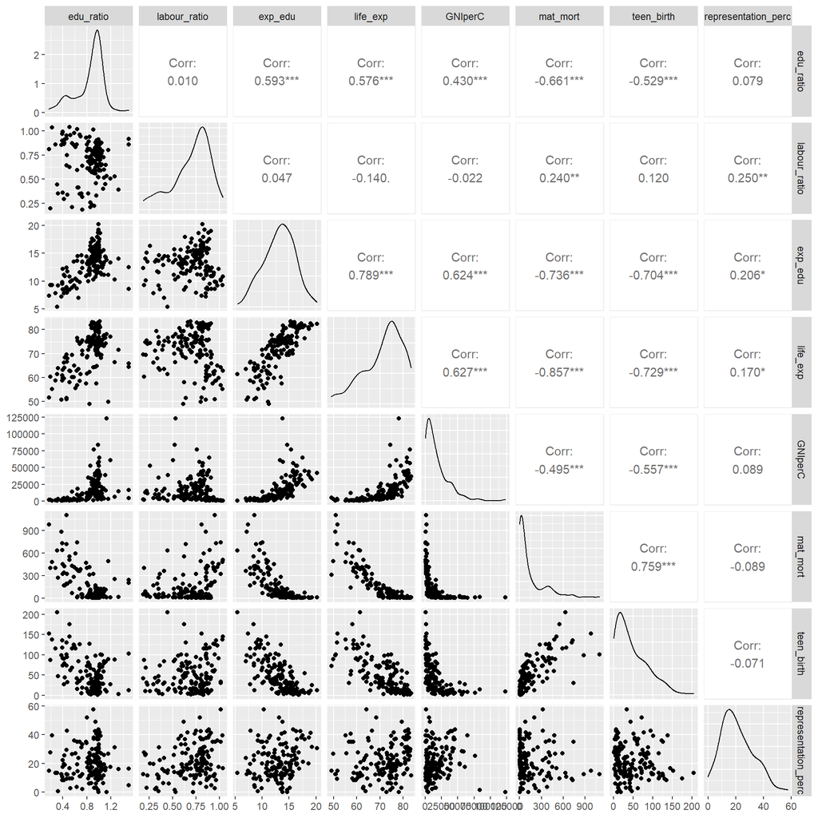

```r
ggpairs(human)
```

Based on the plot above the variables exp_edu, edu_ratio and labour_ratio look like they approximately follow the normal distribution while it looks like the other variables do not.

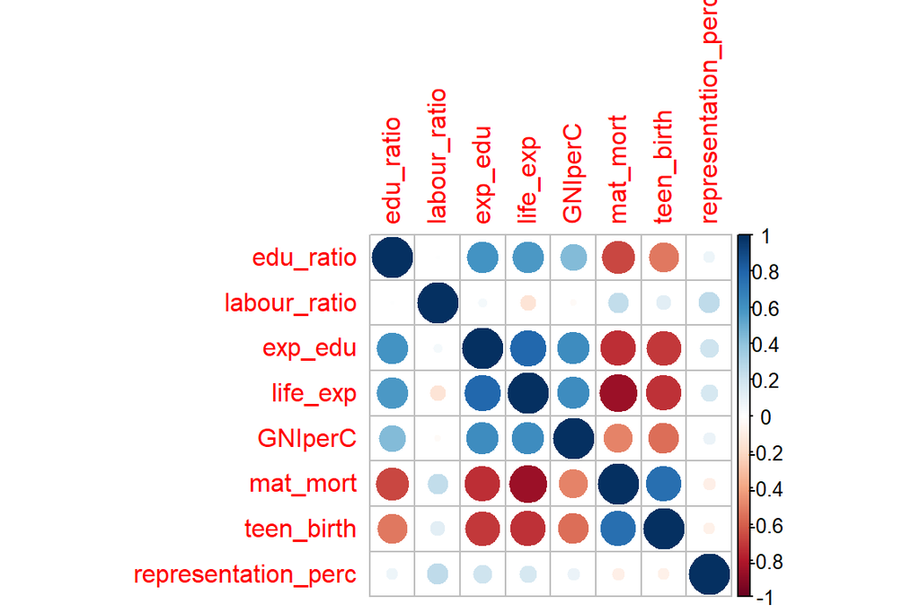

```r
cor(human) %>% corrplot()
```

Based on the correlations there seems to be a postive correlation between maternal mortality rate and the rate of teen births, the value of the correlation is 0.759. As a result there’s a negative correlation between life expectancy and these two variables. Another variable that has a negative correlation between the two first variables is expected education. Similarly there is a negative correlation with the ratio of female and male educational attainment and the GNI of the country and the two first variables. Based on these data it can be said that countries with poor education attainment for women have high teen birth rates and high maternal mortality rates and that these countries are overall poorer than countries that have high educational attainment for women and low maternal mortality rates.

Principal component analysis of the data:

```r
pca <- prcomp(human)
pca_s <- prcomp(scale(human))
```

```r
pca
```

```
## Standard deviations (1, .., p=8):
## [1] 1.854416e+04 1.855219e+02 2.518701e+01 1.145441e+01 3.766241e+00
## [6] 1.565912e+00 1.912052e-01 1.591112e-01
##
## Rotation (n x k) = (8 x 8):
##                               PC1           PC2           PC3           PC4
## edu_ratio            5.607472e-06 -0.0006713951 -3.412027e-05 -2.736326e-04
## labour_ratio        -2.331945e-07  0.0002819357  5.302884e-04 -4.692578e-03
## exp_edu              9.562910e-05 -0.0075529759  1.427664e-02 -3.313505e-02
## life_exp             2.815823e-04 -0.0283150248  1.294971e-02 -6.752684e-02
## GNIperC              9.999832e-01  0.0057723054 -5.156742e-04  4.932889e-05
## mat_mort            -5.655734e-03  0.9916320120  1.260302e-01 -6.100534e-03
## teen_birth          -1.233961e-03  0.1255502723 -9.918113e-01  5.301595e-03
## representation_perc  5.526460e-05 -0.0032317269 -7.398331e-03 -9.971232e-01
##                               PC5           PC6           PC7           PC8
## edu_ratio            0.0022935252  2.180183e-02 -6.998623e-01  7.139410e-01
## labour_ratio        -0.0022190154  3.264423e-02 -7.132267e-01 -7.001533e-01
## exp_edu             -0.1431180282  9.882477e-01  3.826887e-02  7.776451e-03
## life_exp            -0.9865644425 -1.453515e-01 -5.380452e-03  2.281723e-03
## GNIperC              0.0001135863 -2.711698e-05  8.075191e-07 -1.176762e-06
## mat_mort            -0.0266373214  1.695203e-03 -1.355518e-04  8.371934e-04
## teen_birth          -0.0188618600  1.273198e-02  8.641234e-05 -1.707885e-04
## representation_perc  0.0716401914 -2.309896e-02  2.642548e-03  2.680113e-03
```

```r
s1 <- round(100*summary(pca)$importance[2,], digits = 2)
s1 #variability captured by the PCA components without standardisation
```

```
##   PC1   PC2   PC3   PC4   PC5   PC6   PC7   PC8
## 99.99  0.01  0.00  0.00  0.00  0.00  0.00  0.00
```

```r
pca_s
```

```
## Standard deviations (1, .., p=8):
## [1] 2.0708380 1.1397204 0.8750485 0.7788630 0.6619563 0.5363061 0.4589994
## [8] 0.3222406
##
## Rotation (n x k) = (8 x 8):
##                             PC1         PC2         PC3         PC4        PC5
## edu_ratio            0.35664370 -0.03796058 -0.24223089  0.62678110 -0.5983585
## labour_ratio        -0.05457785 -0.72432726 -0.58428770  0.06199424  0.2625067
## exp_edu              0.42766720 -0.13940571 -0.07340270 -0.07020294  0.1659678
## life_exp             0.44372240  0.02530473  0.10991305 -0.05834819  0.1628935
## GNIperC              0.35048295 -0.05060876 -0.20168779 -0.72727675 -0.4950306
## mat_mort            -0.43697098 -0.14508727 -0.12522539 -0.25170614 -0.1800657
## teen_birth          -0.41126010 -0.07708468  0.01968243  0.04986763 -0.4672068
## representation_perc  0.08438558 -0.65136866  0.72506309  0.01396293 -0.1523699
##                             PC6         PC7         PC8
## edu_ratio            0.17713316  0.05773644  0.16459453
## labour_ratio        -0.03500707 -0.22729927 -0.07304568
## exp_edu             -0.38606919  0.77962966 -0.05415984
## life_exp            -0.42242796 -0.43406432  0.62737008
## GNIperC              0.11120305 -0.13711838 -0.16961173
## mat_mort             0.17370039  0.35380306  0.72193946
## teen_birth          -0.76056557 -0.06897064 -0.14335186
## representation_perc  0.13749772  0.00568387 -0.02306476
```

```r
s2 <- round(100*summary(pca_s)$importance[2,], digits = 2)
s2 #variability captured by PCA when data has been standardised
```

```
##   PC1   PC2   PC3   PC4   PC5   PC6   PC7   PC8
## 53.61 16.24  9.57  7.58  5.48  3.60  2.63  1.30
```

```r
s1_lab <- paste0(names(s1), " (", s1, "%)")
s2_lab <- paste0(names(s2), " (", s2, "%)")
```

When not standardising data the first component captures 99% of the variance in the data while in the standardised data it is 53%, which is much more reasonable. The variance captured by the components after standardisation is quite different, but not surprising. As seen in the first plot most of the variables do not follow normal distribution while PCA works better if the variables follow a normal distribution as then the components are independent from each other. Doing PCA on non-standardised data can result in unintuitive results.

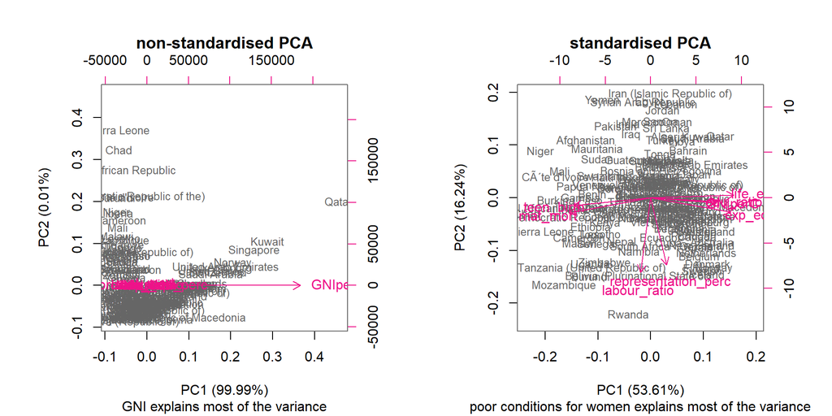

```r
par(mfrow = c(1,2))
biplot(pca, choices = 1:2, cex = c(0.8, 1), col = c("grey40", "deeppink2"), xlab = s1_lab[1], ylab = s1_lab[2], main = "non-standardised PCA", sub = "GNI explains most of the variance")
biplot(pca_s, choices = 1:2, cex = c(0.8, 1), col = c("grey40", "deeppink2"), xlab = s2_lab[1], ylab = s2_lab[2], main = "standardised PCA", sub = "poor conditions for women explains most of the variance")
```

In the two above plots we can see that in the non-standardised data most of the variance can be explained by the GNI of the country and it seems to explain the vast majority of the first PCA component. It is not surprisign that GNI seems to be the most important factor in this case as it correlated in the corrplot with almost all variables and thus may capture all of the variance explained by these other variables too.

In the standardised biplot we can see that there are two clear components. The first component seems to have been able to separate out the effects of the other variables more clearly rather than just lumping them all under GNI. The first component seems to mostly relate to the living conditions of women as the arrows for teen births and maternal mortality point away from expected education and life expectancy which had a negative correlation with the first two variables mentioned. The second component seems to consist of the two variables that GNI did not correlate with strongly, these would be labour ratio between women and men and the representation of women in the parliament. It seems like this component captures information about the participation of women in the economy and political life while the first component is more about general prospects for women or about general poverty.

Multiple correspondence analysis:

```r
library(FactoMineR)
library(tidyr)

data(tea)

dim(tea)
```

```
## [1] 300  36
```

```r
str(tea)
```

```
## 'data.frame':    300 obs. of  36 variables:
##  $ breakfast       : Factor w/ 2 levels "breakfast","Not.breakfast": 1 1 2 2 1 2 1 2 1 1 ...
##  $ tea.time        : Factor w/ 2 levels "Not.tea time",..: 1 1 2 1 1 1 2 2 2 1 ...
##  $ evening         : Factor w/ 2 levels "evening","Not.evening": 2 2 1 2 1 2 2 1 2 1 ...
##  $ lunch           : Factor w/ 2 levels "lunch","Not.lunch": 2 2 2 2 2 2 2 2 2 2 ...
##  $ dinner          : Factor w/ 2 levels "dinner","Not.dinner": 2 2 1 1 2 1 2 2 2 2 ...
##  $ always          : Factor w/ 2 levels "always","Not.always": 2 2 2 2 1 2 2 2 2 2 ...
##  $ home            : Factor w/ 2 levels "home","Not.home": 1 1 1 1 1 1 1 1 1 1 ...
##  $ work            : Factor w/ 2 levels "Not.work","work": 1 1 2 1 1 1 1 1 1 1 ...
##  $ tearoom         : Factor w/ 2 levels "Not.tearoom",..: 1 1 1 1 1 1 1 1 1 2 ...
##  $ friends         : Factor w/ 2 levels "friends","Not.friends": 2 2 1 2 2 2 1 2 2 2 ...
##  $ resto           : Factor w/ 2 levels "Not.resto","resto": 1 1 2 1 1 1 1 1 1 1 ...
##  $ pub             : Factor w/ 2 levels "Not.pub","pub": 1 1 1 1 1 1 1 1 1 1 ...
##  $ Tea             : Factor w/ 3 levels "black","Earl Grey",..: 1 1 2 2 2 2 2 1 2 1 ...
##  $ How             : Factor w/ 4 levels "alone","lemon",..: 1 3 1 1 1 1 1 3 3 1 ...
```

[output cut: 22 more lines]

The tea data set has 36 variables and 300 observations with all variables seemingly being factor variables with at least 2 levels, except for age which is numeric.

Since there are so many variables lets limit it a bit to make the analysis easier:

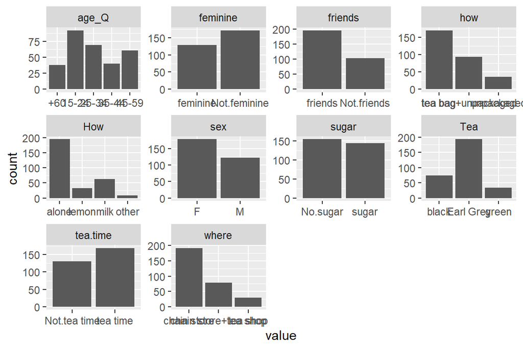

```r
keep_columns <- c("Tea", "How", "how", "sugar", "where", "tea.time", "age_Q", "feminine", "sex", "friends")

tea_time <- subset(tea, select = keep_columns)

gather(tea_time) %>% ggplot(aes(value)) + facet_wrap("key", scales = "free") + geom_bar()
```

The age distribution seems to favour younger people. It also seems like there were more female participants in the questionnaire. Based on the graphs we can also see that Earl Grey tea was the most popular tea and that most people used tea bags for steeping their tea and that most did not add lemon or milk to their tea while with sugar approximately half of the people added sugar to their tea while the other half did not.

```r
mca <- MCA(tea_time, graph = FALSE)
summary(mca)
```

```
##
## Call:
## MCA(X = tea_time, graph = FALSE)
##
##
## Eigenvalues
##                        Dim.1   Dim.2   Dim.3   Dim.4   Dim.5   Dim.6   Dim.7
## Variance               0.197   0.191   0.165   0.144   0.127   0.113   0.105
## % of var.             10.936  10.592   9.189   7.994   7.056   6.295   5.819
## Cumulative % of var.  10.936  21.528  30.716  38.711  45.767  52.062  57.881
##                        Dim.8   Dim.9  Dim.10  Dim.11  Dim.12  Dim.13  Dim.14
## Variance               0.099   0.090   0.086   0.081   0.077   0.072   0.069
## % of var.              5.495   5.000   4.800   4.494   4.300   3.998   3.848
## Cumulative % of var.  63.376  68.377  73.176  77.670  81.970  85.968  89.816
##                       Dim.15  Dim.16  Dim.17  Dim.18
## Variance               0.060   0.050   0.040   0.032
## % of var.              3.360   2.776   2.249   1.800
## Cumulative % of var.  93.176  95.952  98.200 100.000
##
## Individuals (the 10 first)
##                       Dim.1    ctr   cos2    Dim.2    ctr   cos2    Dim.3
## 1                  |  0.569  0.548  0.181 | -0.072  0.009  0.003 | -0.245
## 2                  |  0.249  0.105  0.035 |  0.041  0.003  0.001 | -0.780
## 3                  | -0.220  0.082  0.048 | -0.139  0.034  0.019 | -0.382
## 4                  |  0.535  0.484  0.257 | -0.653  0.746  0.383 |  0.059
## 5                  |  0.519  0.456  0.213 | -0.207  0.075  0.034 | -0.430
## 6                  |  0.430  0.313  0.168 | -0.487  0.415  0.215 | -0.162
## 7                  | -0.003  0.000  0.000 | -0.068  0.008  0.003 | -0.075
## 8                  | -0.232  0.091  0.027 |  0.151  0.040  0.011 | -0.815
## 9                  | -0.203  0.070  0.019 |  0.350  0.214  0.057 |  0.217
## 10                 |  0.076  0.010  0.003 |  0.505  0.445  0.119 |  0.062
##                       ctr   cos2
## 1                   0.121  0.034 |
## 2                   1.225  0.345 |
## 3                   0.295  0.146 |
## 4                   0.007  0.003 |
## 5                   0.372  0.146 |
## 6                   0.053  0.024 |
## 7                   0.011  0.004 |
## 8                   1.339  0.328 |
```

[output cut: 24 more lines]

```
## tea bag+unpackaged |  0.705  9.423  0.227  8.238 |
## unpackaged         |  0.094  0.063  0.001  0.597 |
##
## Categorical variables (eta2)
##                      Dim.1 Dim.2 Dim.3
## Tea                | 0.104 0.267 0.144 |
## How                | 0.072 0.078 0.123 |
## how                | 0.199 0.460 0.252 |
## sugar              | 0.054 0.132 0.202 |
## where              | 0.348 0.519 0.209 |
## tea.time           | 0.322 0.043 0.005 |
## age_Q              | 0.200 0.400 0.331 |
## feminine           | 0.100 0.002 0.103 |
## sex                | 0.414 0.007 0.086 |
## friends            | 0.155 0.000 0.198 |
```

Overall it seems that none of the dimensions is particularly good at capturing the variance as the first components hover at around 10%. It seems that the tea type affects the first 3 dimensions with the first dimension having a contribution from green tea while the next two dimensions have black and earl grey tea. Another important factor seems to be how the tea was packaged such as tea bag or unpackaged.

lets plot the results:

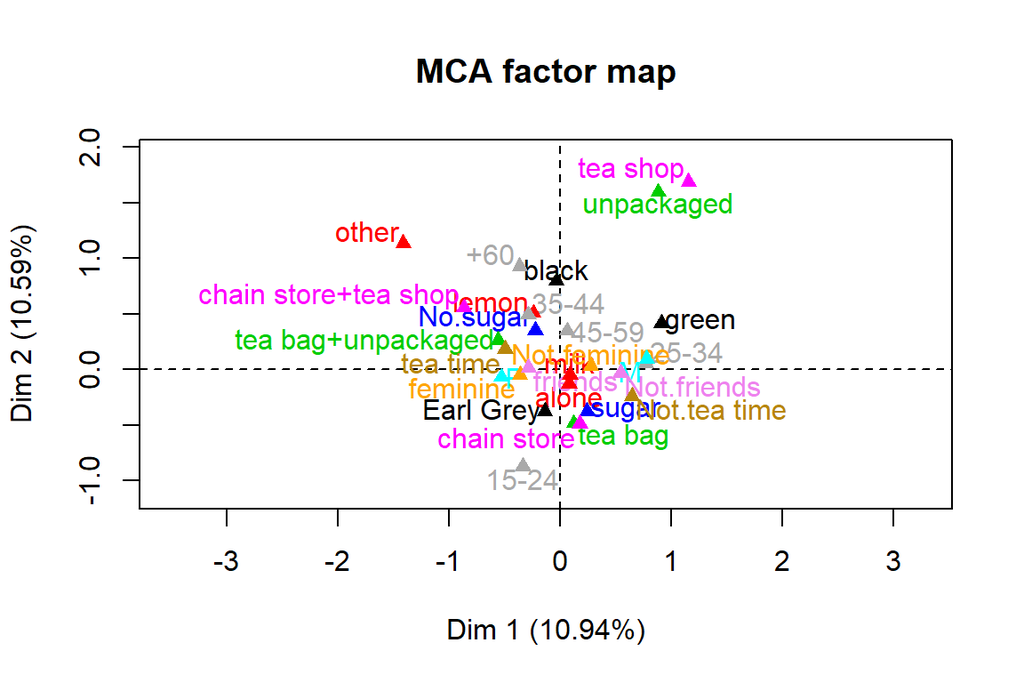

```r
plot(mca, invisible=c("ind"), habillage = "quali", graph.type = "classic")
```

# Week 6, analysis of longitudal data

## Exercise 6

In this exercise we use BPRS data and RATS data. BPRS data is about two treatment groups 40 men were randomly assigned to and they were rated on a psychiatric rating scale, that is supposed to measure if the patient has schizophrenia, at different time points. RATS data consists of data about three different groups of rats that were put on different diets for 9 weeks and their body weights were measured at different time steps.

#### Analysis of RATS data:

```r
library(dplyr)
library(tidyr)
RATSL <- read.table(file='data/RATSL.tsv', sep = '\t')
RATSL$Group <- factor(RATSL$Group)
RATSL$ID <- factor(RATSL$ID)

head(RATSL)
```

```
##   ID Group  WD weight Time
## 1  1     1 WD1    240    1
## 2  2     1 WD1    225    1
## 3  3     1 WD1    245    1
## 4  4     1 WD1    260    1
## 5  5     1 WD1    255    1
## 6  6     1 WD1    260    1
```

The data consists of 5 different variables, we have the ID of the rat in question, the dietary group, weight of the rat and the WD and Time refer to the time steps when the rat was weighted.

Lets make a graph of the rat weights at different time points:

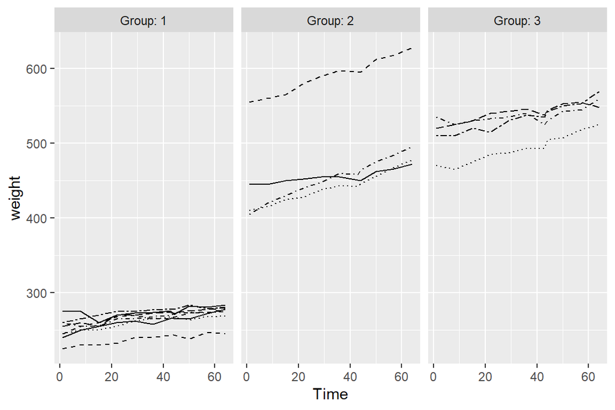

```r
library(ggplot2)
ggplot(RATSL, aes(x = Time, y = weight, linetype = ID)) +
  geom_line() +
  scale_linetype_manual(values = rep(1:10, times=4)) +
  facet_grid(. ~ Group, labeller = label_both) +
  theme(legend.position = "none") +
  scale_y_continuous(limits = c(min(RATSL$weight), max(RATSL$weight)))
```

The rats gain weight in all of the groups as time goes forward, this is not surprising as we can assume that all of the rats either grow or get fat as they have eaten more at later time points. We can however see that in group 1 the rats are leanest while in group 3 they are fattest while group 2 is in the middle except for one outlier.

Lets standardise the data next and make another plot:

```r
RATSL <- RATSL %>%
  group_by(Time) %>%
  mutate(stdweight = (weight - mean(weight))/sd(weight)) %>%
  ungroup()

glimpse(RATSL)
```

```
## Rows: 176
## Columns: 6
## $ ID        <fct> 1, 2, 3, 4, 5, 6, 7, 8, 9, 10, 11, 12, 13, 14, 15, 16, 1, 2,~
## $ Group     <fct> 1, 1, 1, 1, 1, 1, 1, 1, 2, 2, 2, 2, 3, 3, 3, 3, 1, 1, 1, 1, ~
## $ WD        <chr> "WD1", "WD1", "WD1", "WD1", "WD1", "WD1", "WD1", "WD1", "WD1~
## $ weight    <int> 240, 225, 245, 260, 255, 260, 275, 245, 410, 405, 445, 555, ~
## $ Time      <int> 1, 1, 1, 1, 1, 1, 1, 1, 1, 1, 1, 1, 1, 1, 1, 1, 8, 8, 8, 8, ~
## $ stdweight <dbl> -1.0011429, -1.1203857, -0.9613953, -0.8421525, -0.8819001, ~
```

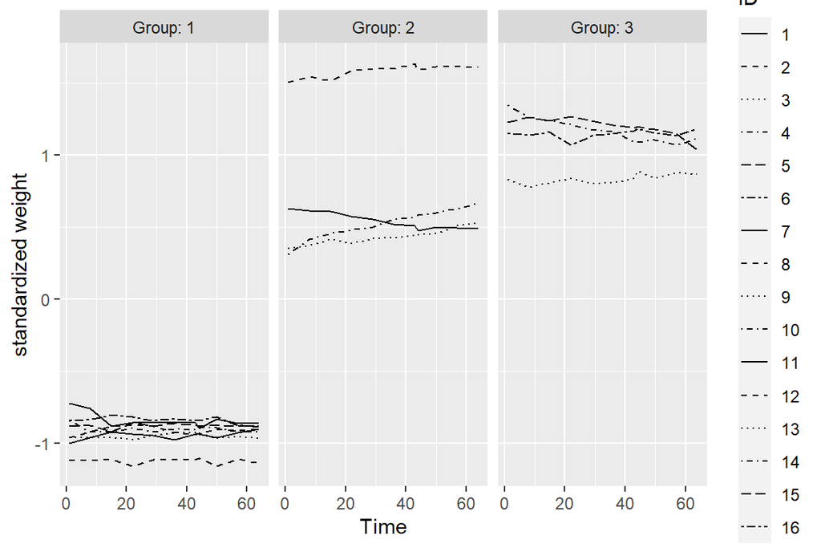

```r
ggplot(RATSL, aes(x = Time, y = stdweight, linetype = ID)) +
  geom_line() +
  scale_linetype_manual(values = rep(1:10, times=4)) +
  facet_grid(. ~ Group, labeller = label_both) +
  scale_y_continuous(name = "standardized weight")
```

Lets make a summary measure next:

```r
n <- RATSL$Time %>% unique() %>% length() #11

RATSS <- RATSL %>%
  group_by(Group, Time) %>%
  summarise( mean = mean(weight), se = (sd(weight)/sqrt(n)))  %>%
  ungroup()
glimpse(RATSS)
```

```
## Rows: 33
## Columns: 4
## $ Group <fct> 1, 1, 1, 1, 1, 1, 1, 1, 1, 1, 1, 2, 2, 2, 2, 2, 2, 2, 2, 2, 2, 2~
## $ Time  <int> 1, 8, 15, 22, 29, 36, 43, 44, 50, 57, 64, 1, 8, 15, 22, 29, 36, ~
## $ mean  <dbl> 250.625, 255.000, 254.375, 261.875, 264.625, 265.000, 267.375, 2~
## $ se    <dbl> 4.589478, 3.947710, 3.460116, 4.100800, 3.333956, 3.552939, 3.30~
```

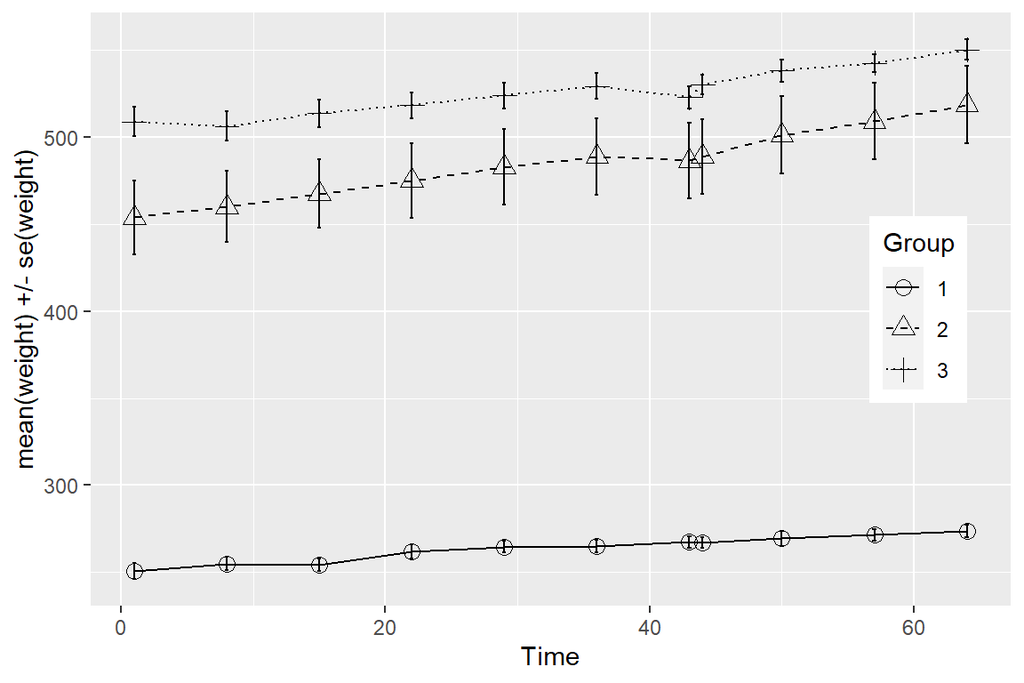

```r
ggplot(RATSS, aes(x = Time, y = mean, linetype = Group, shape = Group)) +
  geom_line() +
  scale_linetype_manual(values = c(1,2,3)) +
  geom_point(size=3) +
  scale_shape_manual(values = c(1,2,3)) +
  geom_errorbar(aes(ymin=mean-se, ymax=mean+se, linetype="1"), width=0.3) +
  theme(legend.position = c(0.9,0.5)) +
  scale_y_continuous(name = "mean(weight) +/- se(weight)")
```

The different groups in the plot above look the same as in the previous plots as in we can see that the weight of the rats increases as time progresses and that group 1 is thinnest and 3 fattest while 2 is between them.

Lets see if there are any outliers in the data that might need to be removed:

```r
RATS_ <- RATSL %>%
  filter(Time > 0) %>%
  group_by(Group, ID) %>%
  summarise( mean=mean(weight) ) %>%
  ungroup()
glimpse(RATS_)
```

```
## Rows: 16
## Columns: 3
## $ Group <fct> 1, 1, 1, 1, 1, 1, 1, 1, 2, 2, 2, 2, 3, 3, 3, 3
## $ ID    <fct> 1, 2, 3, 4, 5, 6, 7, 8, 9, 10, 11, 12, 13, 14, 15, 16
## $ mean  <dbl> 261.0909, 237.6364, 260.1818, 266.5455, 269.4545, 274.7273, 274.~
```

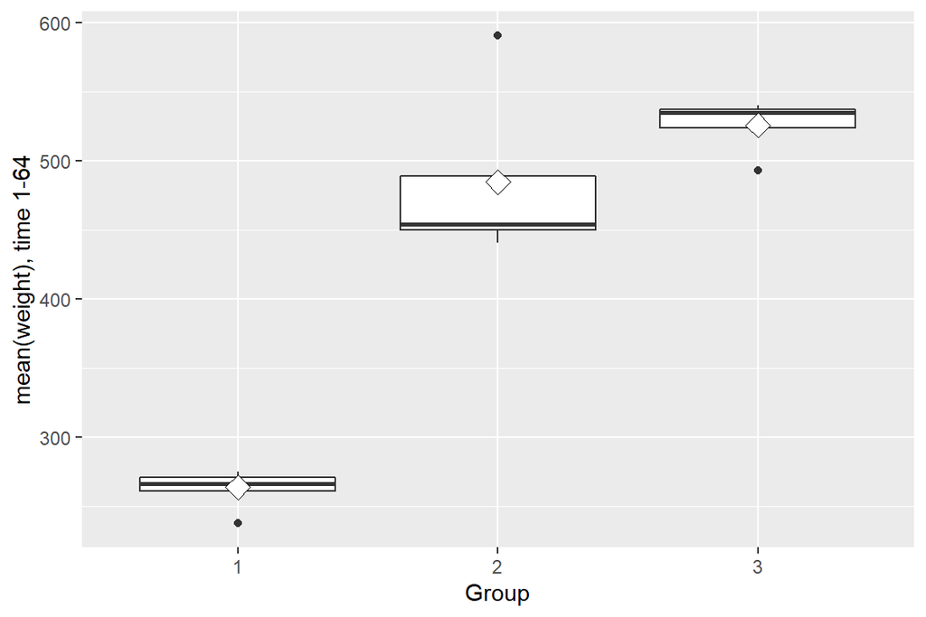

```r
ggplot(RATS_, aes(x = Group, y = mean)) +
  geom_boxplot() +
  stat_summary(fun.y = "mean", geom = "point", shape=23, size=4, fill = "white") +
  scale_y_continuous(name = "mean(weight), time 1-64")
```

There seems to be 3 outliers, lets remove them:

```r
RATS_1 <- filter(RATS_, ((RATS_$mean > 240 & RATS_$mean < 550))   )
RATS_1 <- filter(RATS_1, RATS_1$ID != 13)

glimpse(RATS_1)
```

```
## Rows: 13
## Columns: 3
## $ Group <fct> 1, 1, 1, 1, 1, 1, 1, 2, 2, 2, 3, 3, 3
## $ ID    <fct> 1, 3, 4, 5, 6, 7, 8, 9, 10, 11, 14, 15, 16
## $ mean  <dbl> 261.0909, 260.1818, 266.5455, 269.4545, 274.7273, 274.6364, 265.~
```

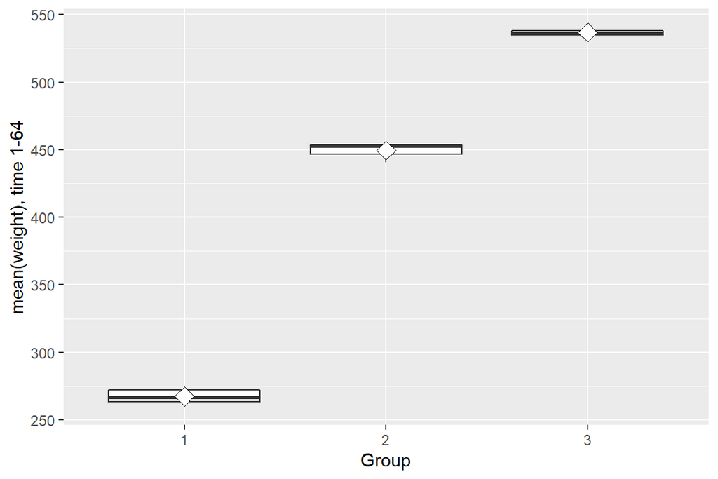

```r
ggplot(RATS_1, aes(x = Group, y = mean)) +
  geom_boxplot() +
  stat_summary(fun.y = "mean", geom = "point", shape=23, size=4, fill = "white") +
  scale_y_continuous(name = "mean(weight), time 1-64")
```

The outliers have been removed, lets see if there are differences between the groups according to a t-test:

```r
t.test(mean ~ Group, data = subset(RATS_1,RATS_1$Group != 1), var.equal = TRUE)
```

```
##
##  Two Sample t-test
##
## data:  mean by Group
## t = -18.428, df = 4, p-value = 5.102e-05
## alternative hypothesis: true difference in means between group 2 and group 3 is not equal to 0
## 95 percent confidence interval:
##  -100.45660  -74.14946
## sample estimates:
## mean in group 2 mean in group 3
##        449.4545        536.7576
```

```r
t.test(mean ~ Group, data = subset(RATS_1,RATS_1$Group != 2), var.equal = TRUE)
```

```
##
##  Two Sample t-test
##
## data:  mean by Group
## t = -73.22, df = 8, p-value = 1.348e-12
## alternative hypothesis: true difference in means between group 1 and group 3 is not equal to 0
## 95 percent confidence interval:
##  -277.7979 -260.8342
## sample estimates:
## mean in group 1 mean in group 3
##        267.4416        536.7576
```

```r
t.test(mean ~ Group, data = subset(RATS_1,RATS_1$Group != 3), var.equal = TRUE)
```

```
##
##  Two Sample t-test
##
## data:  mean by Group
## t = -41.656, df = 8, p-value = 1.215e-10
## alternative hypothesis: true difference in means between group 1 and group 2 is not equal to 0
## 95 percent confidence interval:
##  -192.089 -171.937
## sample estimates:
## mean in group 1 mean in group 2
##        267.4416        449.4545
```

```r
RATS_2 <- RATS_ %>% mutate(baseline = RATSL$weight[RATSL$Time == 1])

fit <- lm(mean ~ baseline + Group, data = RATS_2)

anova(fit)
```

```
## Analysis of Variance Table
##
## Response: mean
##           Df Sum Sq Mean Sq   F value    Pr(>F)
## baseline   1 252125  252125 2237.0655 5.217e-15 ***
## Group      2    726     363    3.2219   0.07586 .
## Residuals 12   1352     113
## ---
## Signif. codes:  0 '***' 0.001 '**' 0.01 '*' 0.05 '.' 0.1 ' ' 1
```

Based on the individual t-tests test statistics and p-values we can see that none of the groups have similar means thus the alternative hypothesis that the groups do not have similar means holds. The anova test we can see that baseline has a very low p-value and a large tests statistic thus it seems like the start weight of the rats is more important in this analysis rather than the diet the rats were put on.

#### Analysis of BPRS data:

```r
BPRSL <- read.table(file='data/BPRSL.tsv', sep = '\t')
BPRSL$treatment <- factor(BPRSL$treatment)
BPRSL$subject <- factor(BPRSL$subject)

dim(BPRSL) #360, 5
```

```
## [1] 360   5
```

```r
head(BPRSL)
```

```
##   treatment subject weeks bprs week
## 1         1       1 week0   42    0
## 2         1       2 week0   58    0
## 3         1       3 week0   54    0
## 4         1       4 week0   55    0
## 5         1       5 week0   72    0
## 6         1       6 week0   48    0
```

Again the data set has 5 variables that are the treatment group, subject ID, the rating on the test (bprs) and the different time points.

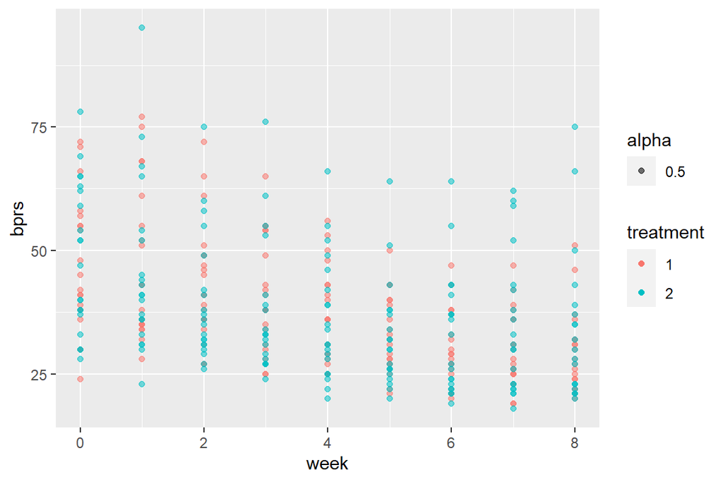

```r
ggplot(BPRSL, aes(x = week, y = bprs, group = subject, col = treatment, alpha = 0.5)) +
  geom_point()
```

```r
#  scale_x_continuous(name = "Time (weeks)") +
#  scale_y_continuous(name = "bprs") +
#  theme(legend.position = "top")
```

The line plot did not work for some reason, so I made a plot with points. I think it is overall hard to say anything about the different treatment groups based on this plot.

Lets do a regression and random intercept models next:

```r
library(lme4)
BPRSL_reg <- lm(bprs ~ week + treatment, data = BPRSL)
summary(BPRSL_reg)
```

```
##
## Call:
## lm(formula = bprs ~ week + treatment, data = BPRSL)
##
## Residuals:
##     Min      1Q  Median      3Q     Max
## -22.454  -8.965  -3.196   7.002  50.244
##
## Coefficients:
##             Estimate Std. Error t value Pr(>|t|)
## (Intercept)  46.4539     1.3670  33.982   <2e-16 ***
## week         -2.2704     0.2524  -8.995   <2e-16 ***
## treatment2    0.5722     1.3034   0.439    0.661
## ---
## Signif. codes:  0 '***' 0.001 '**' 0.01 '*' 0.05 '.' 0.1 ' ' 1
##
## Residual standard error: 12.37 on 357 degrees of freedom
## Multiple R-squared:  0.1851, Adjusted R-squared:  0.1806
## F-statistic: 40.55 on 2 and 357 DF,  p-value: < 2.2e-16
```

```r
BPRSL_ref <- lmer(bprs ~ week + treatment + (1|subject), data = BPRSL, REML = F)
summary(BPRSL_ref)
```

```
## Linear mixed model fit by maximum likelihood  ['lmerMod']
## Formula: bprs ~ week + treatment + (1 | subject)
##    Data: BPRSL
##
##      AIC      BIC   logLik deviance df.resid
##   2748.7   2768.1  -1369.4   2738.7      355
##
## Scaled residuals:
##     Min      1Q  Median      3Q     Max
## -3.0481 -0.6749 -0.1361  0.4813  3.4855
##
## Random effects:
##  Groups   Name        Variance Std.Dev.
##  subject  (Intercept)  47.41    6.885
##  Residual             104.21   10.208
## Number of obs: 360, groups:  subject, 20
##
## Fixed effects:
##             Estimate Std. Error t value
## (Intercept)  46.4539     1.9090  24.334
## week         -2.2704     0.2084 -10.896
## treatment2    0.5722     1.0761   0.532
##
## Correlation of Fixed Effects:
##            (Intr) week
## week       -0.437
## treatment2 -0.282  0.000
```

Based on the regression model the time that passes seems to be the most significant feature and that the treatment does not seem to be that important as it does not have a significant p-value. treatment group 2 also seems to have higher scores in the psychiatric test. The random intercept model again seems to show that the relationship between the intercept and the time that passes is significant. Treatment does not seem to be all that important in this model either.

Lets adjust the random intercept model and make a slope model.

```r
BPRSL_ref1 <- lmer(bprs ~ week + treatment + (week|subject) + (week * treatment), data = BPRSL, REML = F)
summary(BPRSL_ref1)
```

```
## Linear mixed model fit by maximum likelihood  ['lmerMod']
## Formula: bprs ~ week + treatment + (week | subject) + (week * treatment)
##    Data: BPRSL
##
##      AIC      BIC   logLik deviance df.resid
##   2744.3   2775.4  -1364.1   2728.3      352
##
## Scaled residuals:
##     Min      1Q  Median      3Q     Max
## -3.0512 -0.6271 -0.0768  0.5288  3.9260
##
## Random effects:
##  Groups   Name        Variance Std.Dev. Corr
##  subject  (Intercept) 64.9964  8.0620
##           week         0.9687  0.9842   -0.51
##  Residual             96.4707  9.8220
## Number of obs: 360, groups:  subject, 20
##
## Fixed effects:
##                 Estimate Std. Error t value
## (Intercept)      47.8856     2.2521  21.262
## week             -2.6283     0.3589  -7.323
## treatment2       -2.2911     1.9090  -1.200
## week:treatment2   0.7158     0.4010   1.785
##
## Correlation of Fixed Effects:
##             (Intr) week   trtmn2
## week        -0.650
## treatment2  -0.424  0.469
## wek:trtmnt2  0.356 -0.559 -0.840
```

It seems that the subject still adds a huge amount of variance and that time is still somewhat important but not as much as before. Week and treatmnet 2 seem to have some kind of correlation too.

```r
anova(BPRSL_ref, BPRSL_ref1)
```

```
## Data: BPRSL
## Models:
## BPRSL_ref: bprs ~ week + treatment + (1 | subject)
## BPRSL_ref1: bprs ~ week + treatment + (week | subject) + (week * treatment)
##            npar    AIC    BIC  logLik deviance  Chisq Df Pr(>Chisq)
## BPRSL_ref     5 2748.7 2768.1 -1369.4   2738.7
## BPRSL_ref1    8 2744.3 2775.4 -1364.1   2728.3 10.443  3    0.01515 *
## ---
## Signif. codes:  0 '***' 0.001 '**' 0.01 '*' 0.05 '.' 0.1 ' ' 1
```

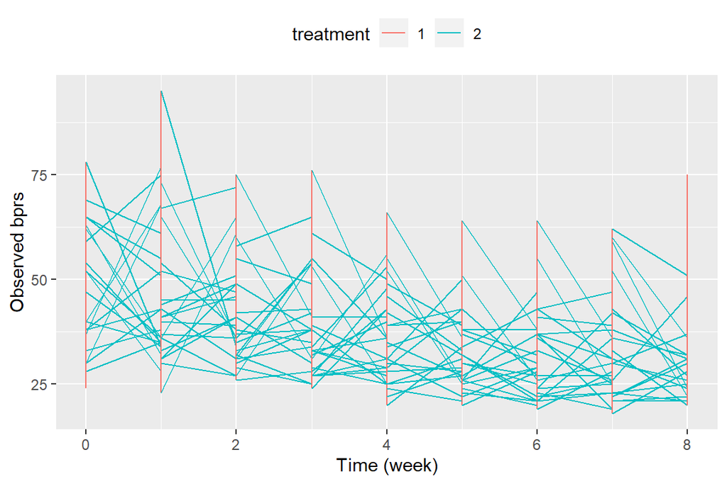

```r
ggplot(BPRSL, aes(x = week, y = bprs, group = subject, col = treatment)) +
  geom_line() +
  scale_x_continuous(name = "Time (week)") +
  scale_y_continuous(name = "Observed bprs") +
  theme(legend.position = "top")
```

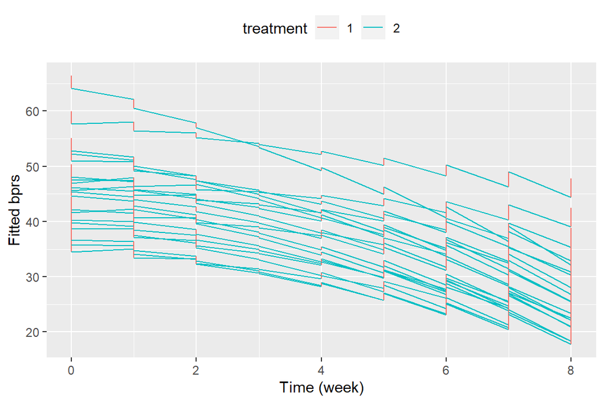

```r
BPRSL$fitted <- fitted(BPRSL_ref1)

ggplot(BPRSL, aes(x = week, y = fitted, group = subject, col = treatment)) +
  geom_line() +
  scale_x_continuous(name = "Time (week)") +
  scale_y_continuous(name = "Fitted bprs") +
  theme(legend.position = "top")
```

The line plots do not work all that well in this either, but in the fitted values plot we can see that the bprs value goes down as the time goes on. We can thus conclude that either both treatments had some kind of effect or that bprs scores going down are related to some other effect that is unrelated to the treatment groups.